# 01. Chapter5 - Interspecific variation in enzyme thermal performance curves

## Model validation

**cs.model.1 [performance]**

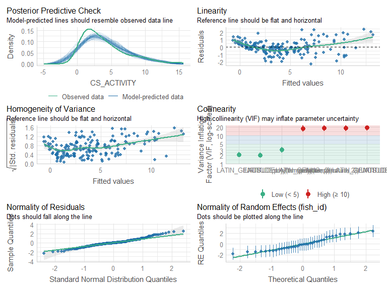

```r
cs.model.1.p2 %>% check_model(detrend = FALSE)
```

**cs.model.1 [DHARMa]**

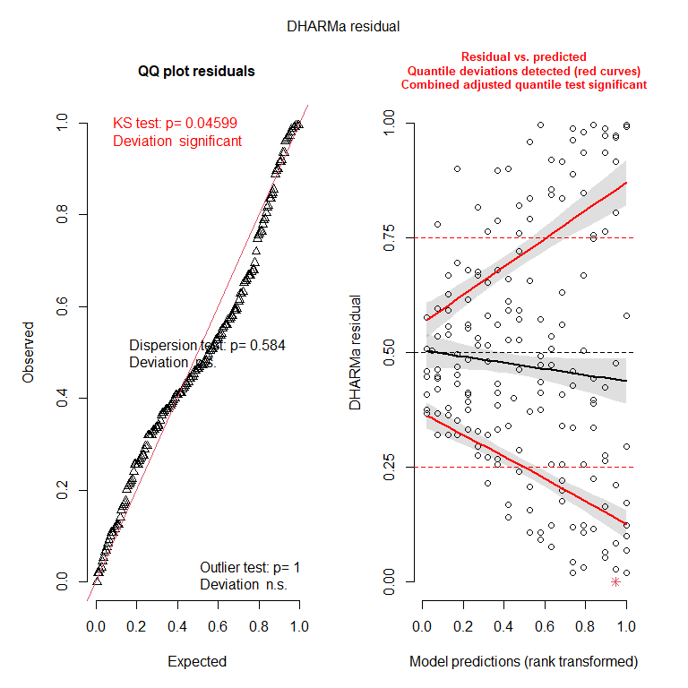

```
Object of Class DHARMa with simulated residuals based on 250 simulations with refit = FALSE . See ?DHARMa::simulateResiduals for help.

Scaled residual values: 0.504 0.4 0.536 0.428 0.376 0.328 0.168 0.076 0.02 0.368 0.296 0.34 0.256 0.12 0.676 0.66 0.856 0.964 0.408 0.276 ...
```

```r
cs.model.1.p2 %>% simulateResiduals(plot=TRUE)
```

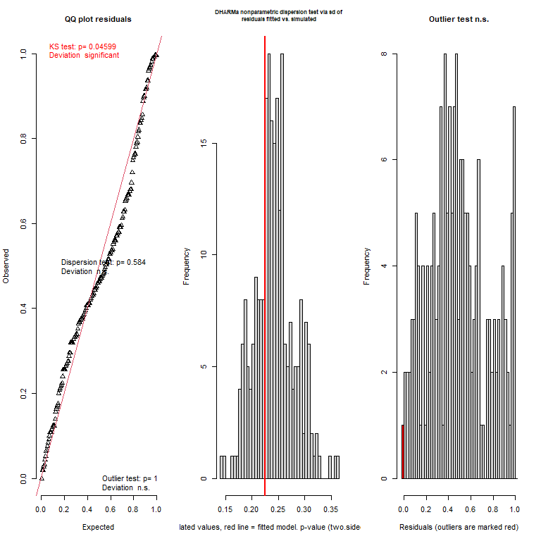

```
$uniformity

    Asymptotic one-sample Kolmogorov-Smirnov test

data:  simulationOutput$scaledResiduals
D = 0.1018, p-value = 0.04599
alternative hypothesis: two-sided


$dispersion

    DHARMa nonparametric dispersion test via sd of residuals fitted vs.
    simulated

data:  simulationOutput
dispersion = 0.93041, p-value = 0.584
alternative hypothesis: two.sided


$outliers

    DHARMa outlier test based on exact binomial test with approximate
    expectations

data:  simulationOutput
outliers at both margin(s) = 1, observations = 182, p-value = 1
alternative hypothesis: true probability of success is not equal to 0.007968127
95 percent confidence interval:
 0.0001390992 0.0302316908
sample estimates:
frequency of outliers (expected: 0.00796812749003984 )
                                           0.005494505
```

```
$uniformity

    Asymptotic one-sample Kolmogorov-Smirnov test

data:  simulationOutput$scaledResiduals
D = 0.1018, p-value = 0.04599
alternative hypothesis: two-sided


$dispersion

    DHARMa nonparametric dispersion test via sd of residuals fitted vs.
    simulated

data:  simulationOutput
dispersion = 0.93041, p-value = 0.584
alternative hypothesis: two.sided


$outliers

    DHARMa outlier test based on exact binomial test with approximate
    expectations

data:  simulationOutput
outliers at both margin(s) = 1, observations = 182, p-value = 1
alternative hypothesis: true probability of success is not equal to 0.007968127
95 percent confidence interval:
 0.0001390992 0.0302316908
sample estimates:
frequency of outliers (expected: 0.00796812749003984 )
                                           0.005494505
```

```r
cs.model.1.p2 %>% DHARMa::testResiduals(plot=TRUE)
```

**cs.model.1 [plot model]**

```
[[2]]
[[2]]$fish_id
```

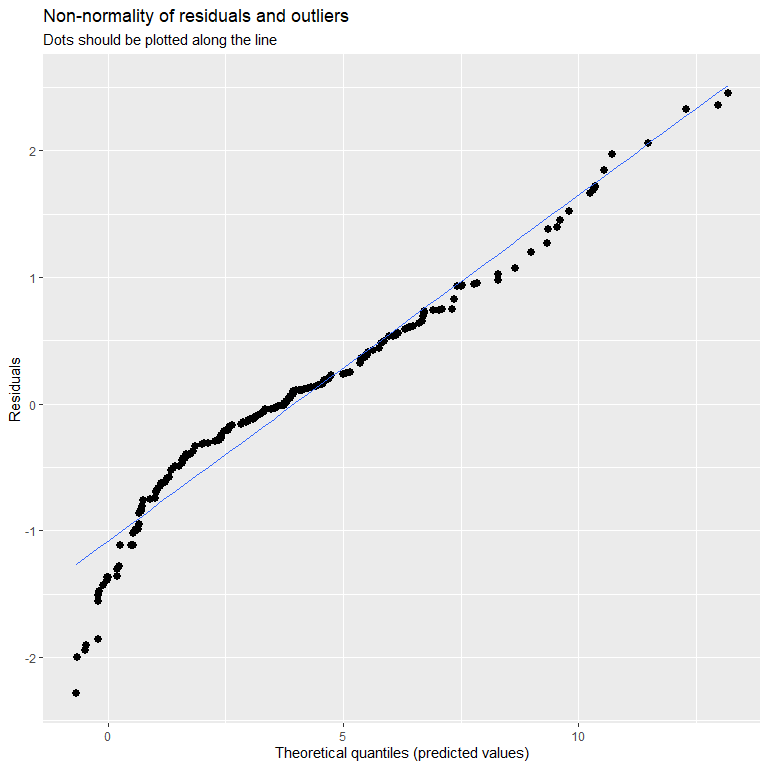

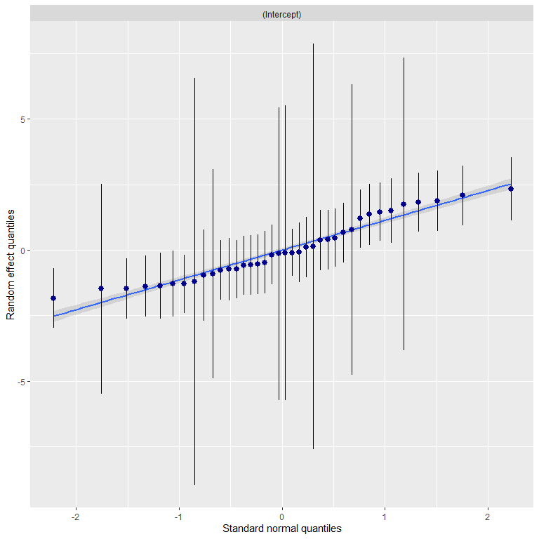

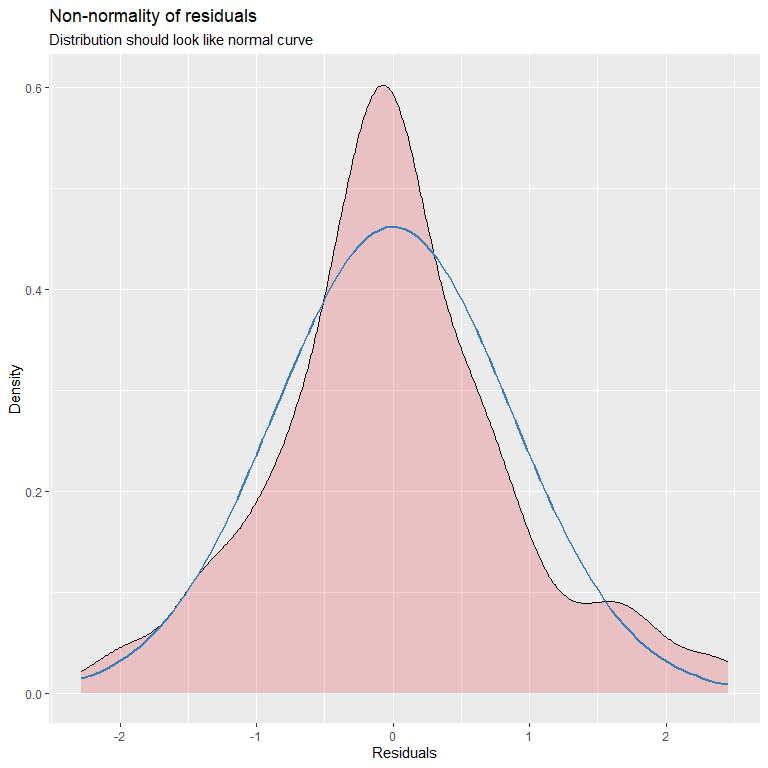

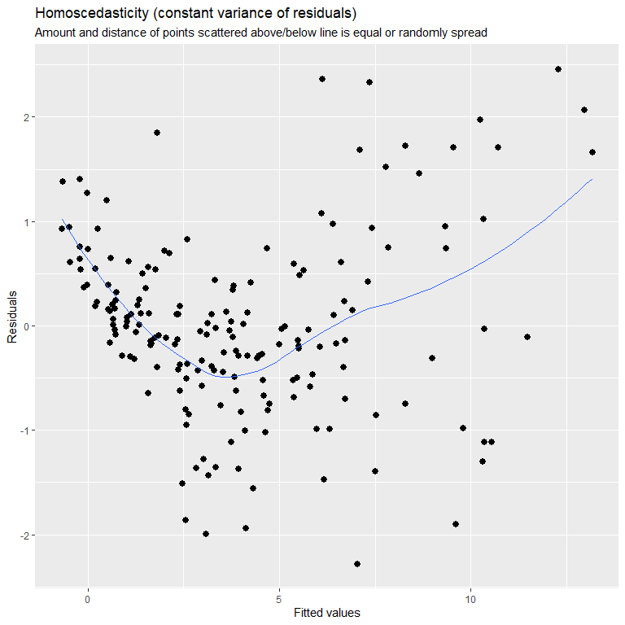

```r
par(mar=c(2,2,2,2))
cs.model.1.p2 %>% plot_model(type = "diag")
```

Issues that come up with the model are the KS test provided by the DHARMa checks and we also see some of the lower values drop off on the qq-plot provided by the ‘check_model’ function. Let’s see if we can fix some of this issues by changing the link function within our distributions.

## Re-fitting model

Turn **REML** off when comparing models

### re-fitting models [link functions]

```r
cs.model.1.p2 <-  cs.model.1.p2 %>% update(REML = FALSE)
cs.model.1.p2.log <- cs.model.1.p2 %>% update(family=gaussian(link="log"),
                                              REML=FALSE)
cs.model.1.p2.sqrt <- cs.model.1.p2 %>% update(family=gaussian(link="sqrt"),
                                               REML=FALSE)
```

### re-fit model comparisons [link function]

```r
aic.c=AICc(cs.model.1.p2, cs.model.1.p2.log, cs.model.1.p2.sqrt,  k=4)
bic=BIC(cs.model.1.p2, cs.model.1.p2.log, cs.model.1.p2.sqrt)

model.fit.table <- as.data.frame(aic.c) %>%
  tibble::rownames_to_column("model") %>%
  mutate(BIC = bic$BIC,
         r2 = c(r.squaredGLMM(cs.model.1.p2)[1], r.squaredGLMM(cs.model.1.p2.log)[1], r.squaredGLMM(cs.model.1.p2.sqrt)[1]))
model.fit.table %>% knitr::kable(format = "html")  %>%
  kable_paper(full_width = TRUE)
```

| model | df | AICc | BIC | r2 |
| --- | --- | --- | --- | --- |
| cs.model.1.p2 | 14 | 642.8919 | 654.7181 | 0.7729074 |
| cs.model.1.p2.log | 14 | 433.1117 | 444.9378 | 0.6636456 |
| cs.model.1.p2.sqrt | 14 | 484.7479 | 496.5741 | 0.5671737 |

```r
anova(cs.model.1.p2, cs.model.1.p2.log, cs.model.1.p2.sqrt, test = "Chisq")
```

|  | Df | AIC | BIC | logLik | deviance | Chisq | Chi Df | Pr(>Chisq) |
| --- | --- | --- | --- | --- | --- | --- | --- | --- |
| cs.model.1.p2 | 14 | 609.8620 | 654.7181 | -290.9310 | 581.8620 | NA | NA | NA |
| cs.model.1.p2.log | 14 | 400.0817 | 444.9378 | -186.0409 | 372.0817 | 209.7802 | 0 | 0 |
| cs.model.1.p2.sqrt | 14 | 451.7180 | 496.5741 | -211.8590 | 423.7180 | 0.0000 | 0 | 1 |

|  | Df <dbl> | AIC <dbl> | BIC <dbl> | logLik <dbl> | deviance <dbl> | Chisq <dbl> | Chi Df <dbl> | Pr(>Chisq) <dbl> |
| --- | --- | --- | --- | --- | --- | --- | --- | --- |
| cs.model.1.p2 | 14 | 609.8620 | 654.7181 | -290.9310 | 581.8620 | NA | NA | NA |
| cs.model.1.p2.log | 14 | 400.0817 | 444.9378 | -186.0409 | 372.0817 | 209.7802 | 0 | 0 |
| cs.model.1.p2.sqrt | 14 | 451.7180 | 496.5741 | -211.8590 | 423.7180 | 0.0000 | 0 | 1 |

3 rows

From this model comparison it looks like the model that uses the **log** link function helps improve our model. Lets see how the model validation looks. We will run the model one more time with **REML=TRUE** before looking at model validation outputs.

```r
cs.model.1.p2.log <- cs.model.1.p2.log %>% update(REML = TRUE)
```

## Model re-validation

**cs.model.1.p2.log [performance]**

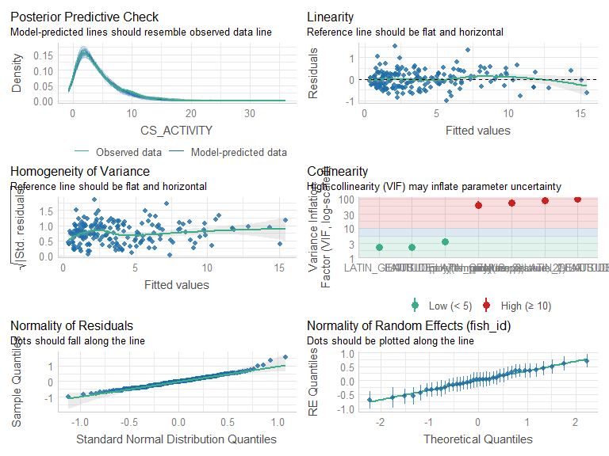

```r
cs.model.1.p2.log %>% check_model(detrend=FALSE)
```

**cs.model.1.p2.log [DHARMa]**

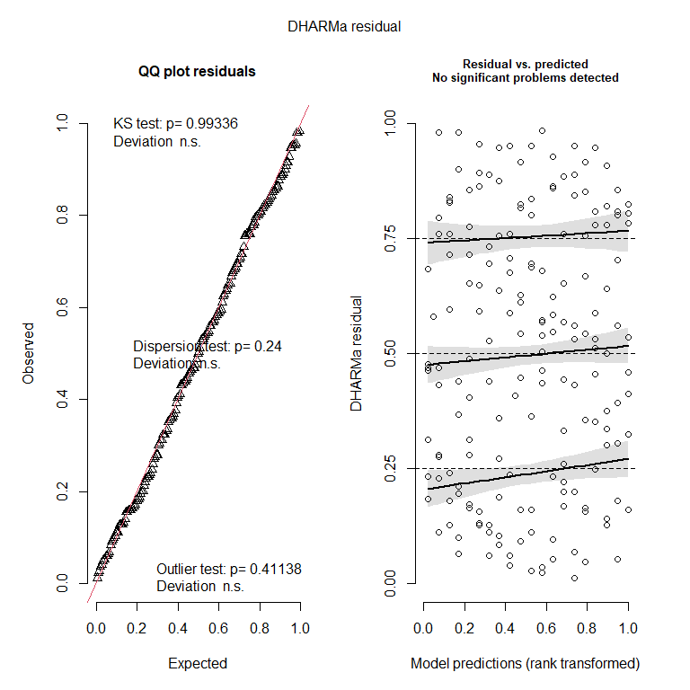

```
## Object of Class DHARMa with simulated residuals based on 250 simulations with refit = FALSE . See ?DHARMa::simulateResiduals for help.
##
## Scaled residual values: 0.58 0.408 0.624 0.532 0.184 0.156 0.04 0.052 0.012 0.232 0.128 0.236 0.232 0.2 0.892 0.76 0.86 0.888 0.312 0.132 ...
```

```r
cs.model.1.p2.log %>% simulateResiduals(plot=TRUE)
```

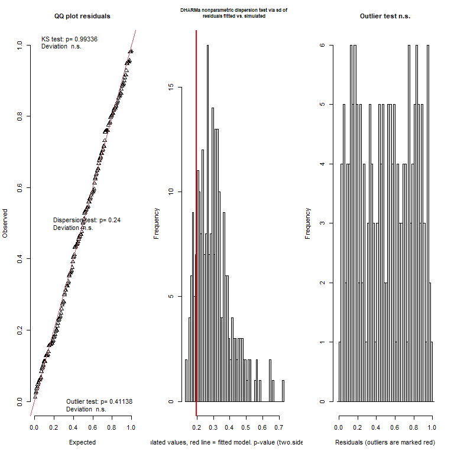

```
## $uniformity
##
##  Asymptotic one-sample Kolmogorov-Smirnov test
##
## data:  simulationOutput$scaledResiduals
## D = 0.031604, p-value = 0.9934
## alternative hypothesis: two-sided
##
##
## $dispersion
##
##  DHARMa nonparametric dispersion test via sd of residuals fitted vs.
##  simulated
##
## data:  simulationOutput
## dispersion = 0.64449, p-value = 0.24
## alternative hypothesis: two.sided
##
##
## $outliers
##
##  DHARMa outlier test based on exact binomial test with approximate
##  expectations
##
## data:  simulationOutput
## outliers at both margin(s) = 0, observations = 182, p-value = 0.4114
## alternative hypothesis: true probability of success is not equal to 0.007968127
## 95 percent confidence interval:
##  0.00000000 0.02006454
## sample estimates:
## frequency of outliers (expected: 0.00796812749003984 )
##                                                      0
```

```
## $uniformity
##
##  Asymptotic one-sample Kolmogorov-Smirnov test
##
## data:  simulationOutput$scaledResiduals
## D = 0.031604, p-value = 0.9934
## alternative hypothesis: two-sided
##
##
## $dispersion
##
##  DHARMa nonparametric dispersion test via sd of residuals fitted vs.
##  simulated
##
## data:  simulationOutput
## dispersion = 0.64449, p-value = 0.24
## alternative hypothesis: two.sided
##
##
## $outliers
##
##  DHARMa outlier test based on exact binomial test with approximate
##  expectations
##
## data:  simulationOutput
## outliers at both margin(s) = 0, observations = 182, p-value = 0.4114
## alternative hypothesis: true probability of success is not equal to 0.007968127
## 95 percent confidence interval:
##  0.00000000 0.02006454
## sample estimates:
## frequency of outliers (expected: 0.00796812749003984 )
##                                                      0
```

```r
cs.model.1.p2.log %>% DHARMa::testResiduals(plot=TRUE)
```

**plot_model**

```
##
## [[2]]
## [[2]]$fish_id
```

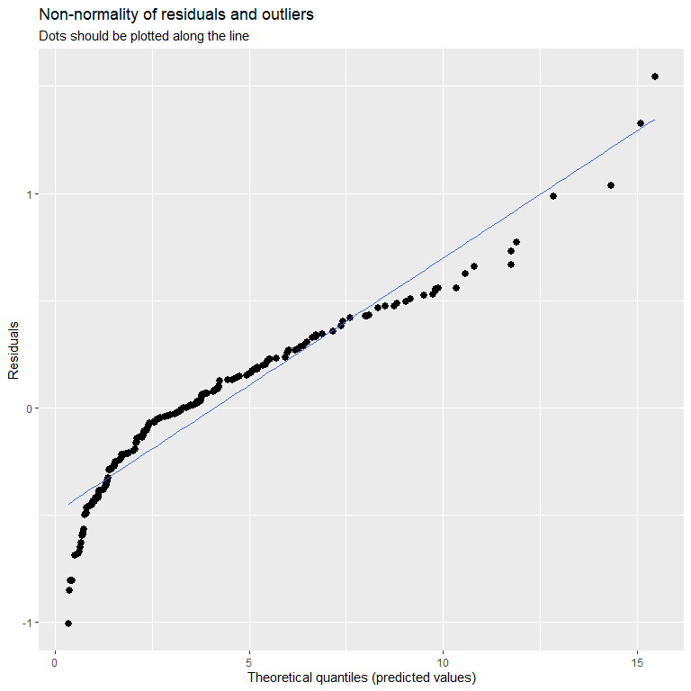

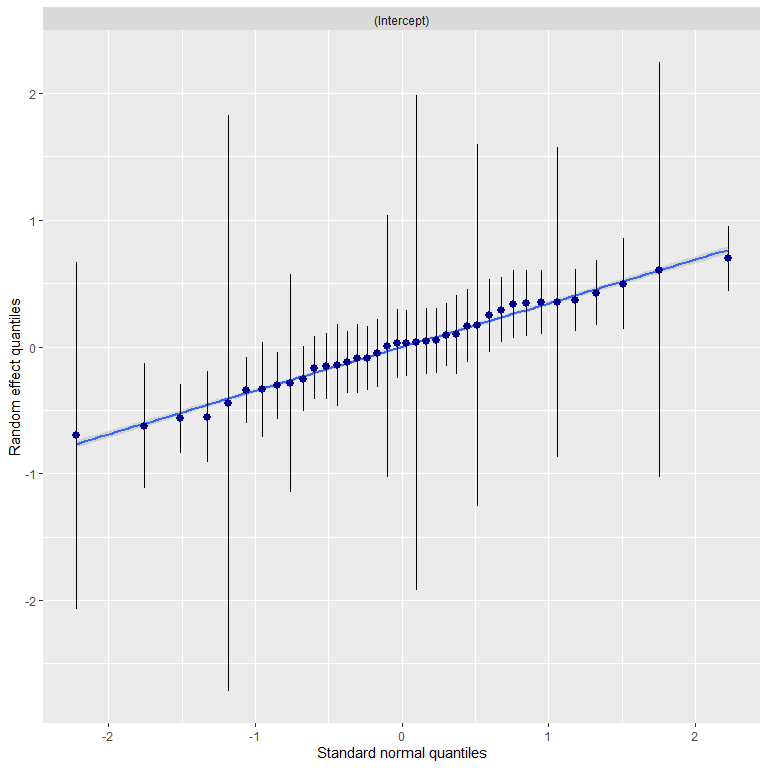

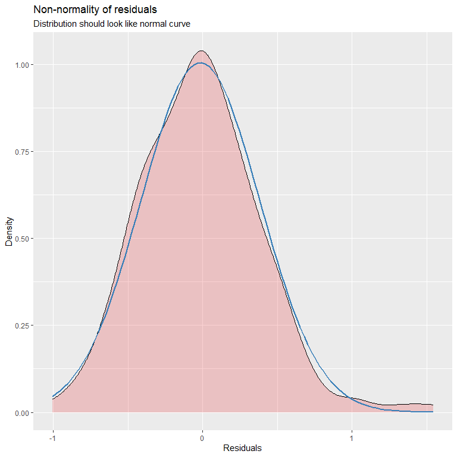

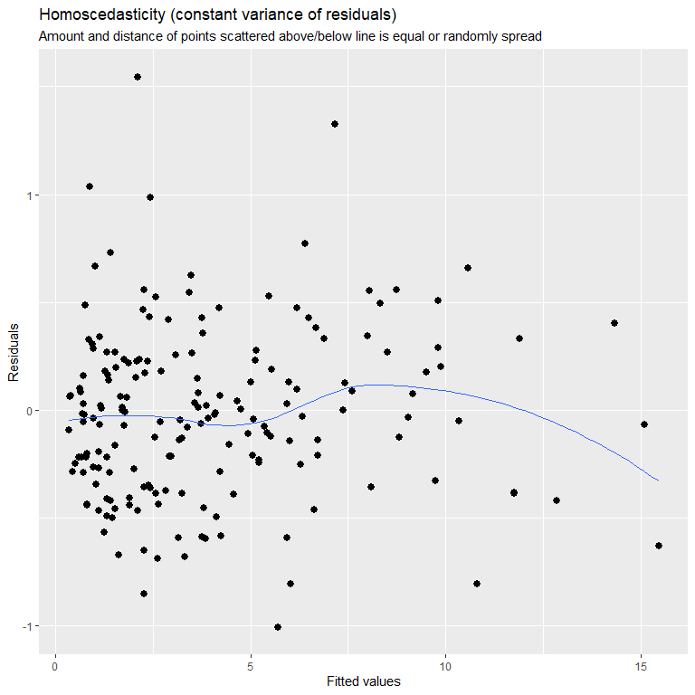

```r
par(mar=c(2,2,2,2))
cs.model.1.p2.log %>% plot_model(type = "diag")
```

### {-}

Model looks much better, there are still some issues with qq plot output from the **plot_model** validations, but otherwise the model looks like it is performing really well. Considering how well the model is performing across most metrics, the current model is judged to be suitable.

## Partial plots

**ggemmeans**

**TEMPERATURE V LATITUDE**

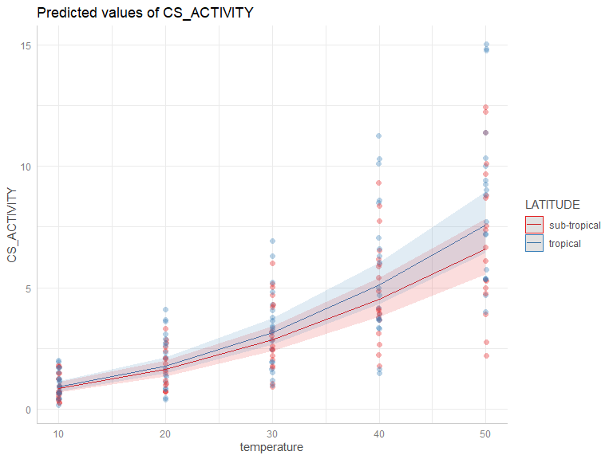

**TEMPERATURE V GENUS**

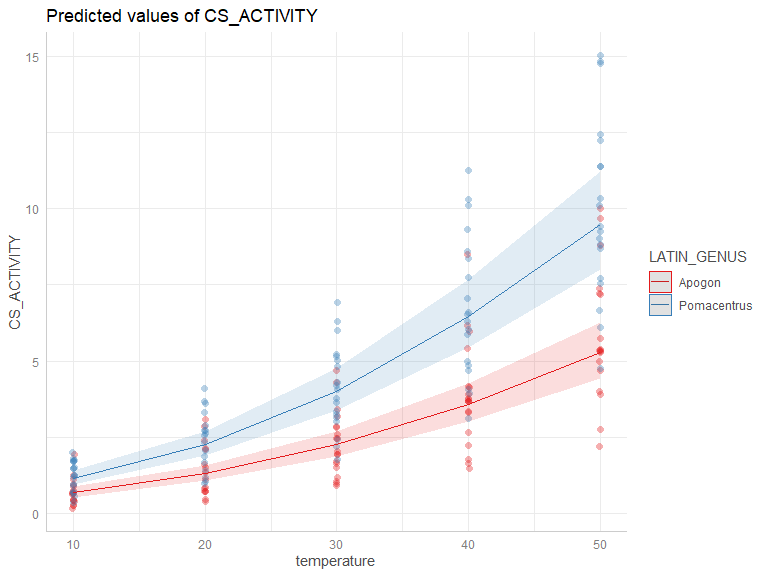

**TEMPERATURE V GENUS V LATITUDE**

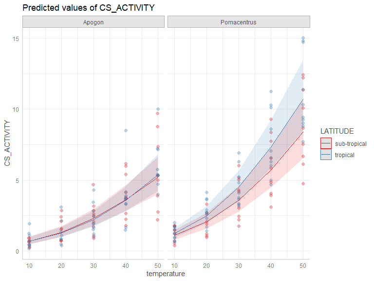

**plot_model**

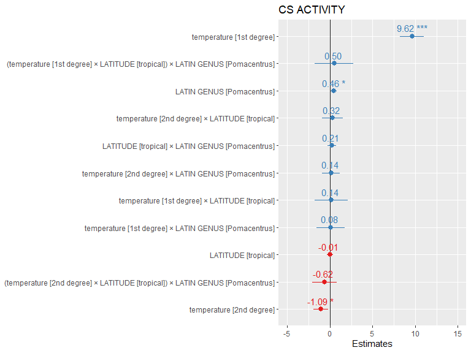

## Model investigation

**summary**

```r
as.data.frame(summary(cs.model.1.p2.log)$coefficients[1]) %>%
  dplyr::rename(
    Estimate = cond.Estimate,
    StdError = cond.Std..Error,
    Zvalue = cond.z.value,
    Pvalue = cond.Pr...z..
    ) %>%
  knitr::kable(format = "html")  %>%
  kable_paper(full_width = TRUE)
```

|  | Estimate | StdError | Zvalue | Pvalue |
| --- | --- | --- | --- | --- |
| (Intercept) | 0.7510157 | 0.1319696 | 5.6908219 | 0.0000000 |
| poly(temperature, 2)1 | 9.6202701 | 0.6988145 | 13.7665575 | 0.0000000 |
| poly(temperature, 2)2 | -1.0934659 | 0.4390221 | -2.4906851 | 0.0127497 |
| LATITUDEtropical | -0.0050903 | 0.1825669 | -0.0278821 | 0.9777562 |
| LATIN_GENUSPomacentrus | 0.4596728 | 0.1830279 | 2.5114903 | 0.0120223 |
| poly(temperature, 2)1:LATITUDEtropical | 0.1406210 | 0.9959936 | 0.1411867 | 0.8877225 |
| poly(temperature, 2)2:LATITUDEtropical | 0.3232856 | 0.6236875 | 0.5183454 | 0.6042173 |
| poly(temperature, 2)1:LATIN_GENUSPomacentrus | 0.0840327 | 0.8357926 | 0.1005425 | 0.9199137 |
| poly(temperature, 2)2:LATIN_GENUSPomacentrus | 0.1439155 | 0.5273767 | 0.2728894 | 0.7849382 |
| LATITUDEtropical:LATIN_GENUSPomacentrus | 0.2098695 | 0.2523627 | 0.8316189 | 0.4056241 |
| poly(temperature, 2)1:LATITUDEtropical:LATIN_GENUSPomacentrus | 0.4993366 | 1.1607065 | 0.4302006 | 0.6670498 |
| poly(temperature, 2)2:LATITUDEtropical:LATIN_GENUSPomacentrus | -0.6159270 | 0.7279050 | -0.8461640 | 0.3974613 |

**anova**

```r
cs.model.1.p2.log %>% Anova() %>%
  as.data.frame() %>%
  knitr::kable(format = "html")  %>%
  kable_paper(full_width = TRUE)
```

|  | Chisq | Df | Pr(>Chisq) |
| --- | --- | --- | --- |
| poly(temperature, 2) | 3424.6394812 | 2 | 0.0000000 |
| LATITUDE | 1.1218967 | 1 | 0.2895104 |
| LATIN_GENUS | 23.4811359 | 1 | 0.0000013 |
| poly(temperature, 2):LATITUDE | 1.4404598 | 2 | 0.4866404 |
| poly(temperature, 2):LATIN_GENUS | 0.3536138 | 2 | 0.8379416 |
| LATITUDE:LATIN_GENUS | 0.8750029 | 1 | 0.3495740 |
| poly(temperature, 2):LATITUDE:LATIN_GENUS | 0.8990948 | 2 | 0.6379168 |

**confint**

```r
cs.model.1.p2.log %>% confint() %>%
  as.data.frame() %>%
  knitr::kable(format = "html")  %>%
  kable_paper(full_width = TRUE)
```

|  | 2.5 % | 97.5 % | Estimate |
| --- | --- | --- | --- |
| (Intercept) | 0.4923600 | 1.0096715 | 0.7510157 |
| poly(temperature, 2)1 | 8.2506188 | 10.9899214 | 9.6202701 |
| poly(temperature, 2)2 | -1.9539334 | -0.2329983 | -1.0934659 |
| LATITUDEtropical | -0.3629149 | 0.3527342 | -0.0050903 |
| LATIN_GENUSPomacentrus | 0.1009447 | 0.8184008 | 0.4596728 |
| poly(temperature, 2)1:LATITUDEtropical | -1.8114906 | 2.0927326 | 0.1406210 |
| poly(temperature, 2)2:LATITUDEtropical | -0.8991195 | 1.5456907 | 0.3232856 |
| poly(temperature, 2)1:LATIN_GENUSPomacentrus | -1.5540907 | 1.7221560 | 0.0840327 |
| poly(temperature, 2)2:LATIN_GENUSPomacentrus | -0.8897238 | 1.1775549 | 0.1439155 |
| LATITUDEtropical:LATIN_GENUSPomacentrus | -0.2847522 | 0.7044913 | 0.2098695 |
| poly(temperature, 2)1:LATITUDEtropical:LATIN_GENUSPomacentrus | -1.7756064 | 2.7742795 | 0.4993366 |
| poly(temperature, 2)2:LATITUDEtropical:LATIN_GENUSPomacentrus | -2.0425946 | 0.8107406 | -0.6159270 |
| Std.Dev.(Intercept)\|fish_id | 0.2874426 | 0.4755286 | 0.3697123 |

**r-squared**

```r
cs.model.1.p2.log %>% performance::r2_nakagawa() %>%
  as.data.frame() %>%
  knitr::kable(format = "html")  %>%
  kable_paper(full_width = TRUE)
```

| R2_conditional | R2_marginal | optional |
| --- | --- | --- |
| 0.7858256 | 0.6449892 | FALSE |

## Pairwise comparisons

**emtrends**

```r
cs.model.1.p2.log %>% emtrends(var = "temperature", type = "response") %>% pairs(by = "temperature") %>% summary(by = NULL, adjust = "sidak", infer=TRUE)
```

|  | contrast | temperature | estimate | SE | df | lower.CL | upper.CL | t.ratio | p.value |
| --- | --- | --- | --- | --- | --- | --- | --- | --- | --- |
| 1 | (sub-tropical Apogon) - tropical Apogon | 30.38462 | -0.0008574003 | 0.005046098 | 180 | -0.01428148 | 0.012566681 | -0.16991354 | 0.9999940 |
| 2 | (sub-tropical Apogon) - (sub-tropical Pomacentrus) | 30.38462 | -0.0004942210 | 0.004233905 | 180 | -0.01175763 | 0.010769191 | -0.11672936 | 0.9999994 |
| 3 | (sub-tropical Apogon) - tropical Pomacentrus | 30.38462 | -0.0037466016 | 0.004031832 | 180 | -0.01447244 | 0.006979240 | -0.92925527 | 0.9273242 |
| 4 | tropical Apogon - (sub-tropical Pomacentrus) | 30.38462 | 0.0003631793 | 0.004280310 | 180 | -0.01102368 | 0.011750043 | 0.08484884 | 0.9999999 |
| 5 | tropical Apogon - tropical Pomacentrus | 30.38462 | -0.0028892012 | 0.004080552 | 180 | -0.01374465 | 0.007966248 | -0.70804182 | 0.9801917 |
| 6 | (sub-tropical Pomacentrus) - tropical Pomacentrus | 30.38462 | -0.0032523806 | 0.003018825 | 180 | -0.01128333 | 0.004778568 | -1.07736637 | 0.8638578 |

|  | contrast <fct> | temperature <dbl> | estimate <dbl> |  |
| --- | --- | --- | --- | --- |
| 1 | (sub-tropical Apogon) - tropical Apogon | 30.38462 | -0.0008574003 |  |
| 2 | (sub-tropical Apogon) - (sub-tropical Pomacentrus) | 30.38462 | -0.0004942210 |  |
| 3 | (sub-tropical Apogon) - tropical Pomacentrus | 30.38462 | -0.0037466016 |  |
| 4 | tropical Apogon - (sub-tropical Pomacentrus) | 30.38462 | 0.0003631793 |  |
| 5 | tropical Apogon - tropical Pomacentrus | 30.38462 | -0.0028892012 |  |
| 6 | (sub-tropical Pomacentrus) - tropical Pomacentrus | 30.38462 | -0.0032523806 |  |

6 rows | 1-4 of 10 columns

**emmeans**

```r
cs.model.1.p2.log %>% emmeans(pairwise ~ temperature*LATITUDE*LATIN_GENUS, type = "response") %>% regrid() %>% pairs(by = "temperature") %>% summary(by = NULL, adjust = "sidak", infer=TRUE)
```

|  | contrast | temperature | estimate | SE | df | lower.CL | upper.CL | t.ratio | p.value |
| --- | --- | --- | --- | --- | --- | --- | --- | --- | --- |
| 1 | (sub-tropical Apogon) - tropical Apogon | 30.38462 | 0.07681331 | 0.4111760 | 180 | -1.017034 | 1.17066055 | 0.1868137 | 0.999989498 |
| 2 | (sub-tropical Apogon) - (sub-tropical Pomacentrus) | 30.38462 | -1.31489405 | 0.5501255 | 180 | -2.778387 | 0.14859920 | -2.3901709 | 0.102558089 |
| 3 | (sub-tropical Apogon) - tropical Pomacentrus | 30.38462 | -2.26037978 | 0.6230814 | 180 | -3.917957 | -0.60280288 | -3.6277441 | 0.002231365 |
| 4 | tropical Apogon - (sub-tropical Pomacentrus) | 30.38462 | -1.39170736 | 0.5372040 | 180 | -2.820826 | 0.03741081 | -2.5906498 | 0.060597802 |
| 5 | tropical Apogon - tropical Pomacentrus | 30.38462 | -2.33719309 | 0.6116965 | 180 | -3.964483 | -0.70990330 | -3.8208379 | 0.001097362 |
| 6 | (sub-tropical Pomacentrus) - tropical Pomacentrus | 30.38462 | -0.94548573 | 0.7125158 | 180 | -2.840984 | 0.95001270 | -1.3269681 | 0.709526935 |

|  | contrast <fct> | temperature <dbl> | estimate <dbl> | SE <dbl> |  |
| --- | --- | --- | --- | --- | --- |
| 1 | (sub-tropical Apogon) - tropical Apogon | 30.38462 | 0.07681331 | 0.4111760 |  |
| 2 | (sub-tropical Apogon) - (sub-tropical Pomacentrus) | 30.38462 | -1.31489405 | 0.5501255 |  |
| 3 | (sub-tropical Apogon) - tropical Pomacentrus | 30.38462 | -2.26037978 | 0.6230814 |  |
| 4 | tropical Apogon - (sub-tropical Pomacentrus) | 30.38462 | -1.39170736 | 0.5372040 |  |
| 5 | tropical Apogon - tropical Pomacentrus | 30.38462 | -2.33719309 | 0.6116965 |  |
| 6 | (sub-tropical Pomacentrus) - tropical Pomacentrus | 30.38462 | -0.94548573 | 0.7125158 |  |

6 rows | 1-5 of 10 columns

**temperature**

```r
cs.model.1.p2.log %>% emmeans(~ temperature*LATITUDE*LATIN_GENUS, type = "response")  %>% summary(infer=TRUE)
```

|  | temperature | LATITUDE | LATIN_GENUS | response | SE | df | lower.CL | upper.CL | null | t.ratio | p.value |
| --- | --- | --- | --- | --- | --- | --- | --- | --- | --- | --- | --- |
| 1 | 30.38462 | sub-tropical | Apogon | 2.332751 | 0.3027074 | 180 | 1.805782 | 3.013502 | 1 | 6.527597 | 6.587921e-10 |
| 2 | 30.38462 | tropical | Apogon | 2.255938 | 0.2785132 | 180 | 1.768187 | 2.878233 | 1 | 6.589824 | 4.704735e-10 |
| 3 | 30.38462 | sub-tropical | Pomacentrus | 3.647645 | 0.4594195 | 180 | 2.844974 | 4.676778 | 1 | 10.274598 | 8.842322e-20 |
| 4 | 30.38462 | tropical | Pomacentrus | 4.593131 | 0.5446284 | 180 | 3.634919 | 5.803939 | 1 | 12.857412 | 2.927177e-27 |

|  | temperature <dbl> | LATITUDE <fct> | LATIN_GENUS <fct> | response <dbl> |  |
| --- | --- | --- | --- | --- | --- |
| 1 | 30.38462 | sub-tropical | Apogon | 2.332751 |  |
| 2 | 30.38462 | tropical | Apogon | 2.255938 |  |
| 3 | 30.38462 | sub-tropical | Pomacentrus | 3.647645 |  |
| 4 | 30.38462 | tropical | Pomacentrus | 4.593131 |  |

4 rows | 1-5 of 12 columns

**temperture [combined]**

```r
cs.means.temp <- cs.model.1.p2.log %>% update(CS_ACTIVITY ~ factor(temperature) * LATITUDE * LATIN_GENUS + (1|fish_id)) %>% emmeans(pairwise ~ temperature, type = "response") %>% summary(infer=TRUE)
```

```
## NOTE: Results may be misleading due to involvement in interactions
```

```r
cs.means.temp.df <- cs.means.temp$emmeans %>% as.data.frame() %>%
  mutate("\u394 change"=response - lag(response, n=1, default = first(response)),
         "\u394 %change" = response/lag(response, n=1, default = first(response))*100)
cs.means.temp.df[1,11] = 0.0000


cs.means.temp.df
```

|  | temperature | response | SE | df | lower.CL | upper.CL | null | t.ratio | p.value | Δ change | Δ %change |
| --- | --- | --- | --- | --- | --- | --- | --- | --- | --- | --- | --- |
| 1 | 10 | 0.8770465 | 0.09412851 | 180 | 0.7096587 | 1.083916 | 1 | -1.222418 | 2.231479e-01 | 0.0000000 | 0.0000 |
| 2 | 20 | 1.7542386 | 0.12986028 | 180 | 1.5158304 | 2.030143 | 1 | 7.592339 | 1.641724e-12 | 0.8771921 | 200.0166 |
| 3 | 30 | 2.9311410 | 0.19119795 | 180 | 2.5771346 | 3.333775 | 1 | 16.486186 | 8.172245e-38 | 1.1769024 | 167.0891 |
| 4 | 40 | 4.8622314 | 0.30268797 | 180 | 4.3001854 | 5.497738 | 1 | 25.404402 | 2.004269e-61 | 1.9310904 | 165.8819 |
| 5 | 50 | 7.0603653 | 0.43383401 | 180 | 6.2541727 | 7.970480 | 1 | 31.808160 | 8.441080e-76 | 2.1981339 | 145.2083 |

|  | temperature <dbl> | response <dbl> | SE <dbl> | df <dbl> |  |
| --- | --- | --- | --- | --- | --- |
| 1 | 10 | 0.8770465 | 0.09412851 | 180 |  |
| 2 | 20 | 1.7542386 | 0.12986028 | 180 |  |
| 3 | 30 | 2.9311410 | 0.19119795 | 180 |  |
| 4 | 40 | 4.8622314 | 0.30268797 | 180 |  |
| 5 | 50 | 7.0603653 | 0.43383401 | 180 |  |

5 rows | 1-5 of 12 columns

**Genus values [combined]**

```r
cs.genus.df <- cs.model.1.p2.log %>% update(CS_ACTIVITY ~ factor(temperature) * LATITUDE * LATIN_GENUS + (1|fish_id)) %>% emmeans(pairwise ~ temperature*LATIN_GENUS, type = "response"); cs.genus.df$emmeans
```

```
## NOTE: Results may be misleading due to involvement in interactions
```

```
##  temperature LATIN_GENUS response    SE  df lower.CL upper.CL
##           10 Apogon         0.642 0.115 180    0.450    0.915
##           20 Apogon         1.388 0.155 180    1.114    1.730
##           30 Apogon         2.160 0.207 180    1.788    2.608
##           40 Apogon         3.633 0.325 180    3.045    4.335
##           50 Apogon         5.269 0.463 180    4.430    6.267
##           10 Pomacentrus    1.198 0.140 180    0.951    1.510
##           20 Pomacentrus    2.217 0.216 180    1.830    2.686
##           30 Pomacentrus    3.978 0.353 180    3.340    4.739
##           40 Pomacentrus    6.507 0.563 180    5.485    7.718
##           50 Pomacentrus    9.461 0.812 180    7.987   11.208
##
## Results are averaged over the levels of: LATITUDE
## Confidence level used: 0.95
## Intervals are back-transformed from the log scale
```

**Genus ratios [combined]**

```r
cs.model.1.p2.log %>% update(CS_ACTIVITY ~ factor(temperature) * LATITUDE * LATIN_GENUS + (1|fish_id)) %>% emmeans(pairwise ~ temperature*LATIN_GENUS, type = "response") %>% pairs(by="temperature") %>% summary(infer=FALSE)
```

```
## NOTE: Results may be misleading due to involvement in interactions
```

|  | contrast | temperature | ratio | SE | df |
| --- | --- | --- | --- | --- | --- |
| 1 | Apogon / Pomacentrus | 10 | 0.5358345 | 0.11500546 | 180 |
| 2 | Apogon / Pomacentrus | 20 | 0.6261699 | 0.09268900 | 180 |
| 3 | Apogon / Pomacentrus | 30 | 0.5428289 | 0.07079910 | 180 |
| 4 | Apogon / Pomacentrus | 40 | 0.5583970 | 0.06950390 | 180 |
| 5 | Apogon / Pomacentrus | 50 | 0.5568480 | 0.06840868 | 180 |

|  | contrast <fct> | temperature <fct> | ratio <dbl> | SE <dbl> |  |
| --- | --- | --- | --- | --- | --- |
| 1 | Apogon / Pomacentrus | 10 | 0.5358345 | 0.11500546 |  |
| 2 | Apogon / Pomacentrus | 20 | 0.6261699 | 0.09268900 |  |
| 3 | Apogon / Pomacentrus | 30 | 0.5428289 | 0.07079910 |  |
| 4 | Apogon / Pomacentrus | 40 | 0.5583970 | 0.06950390 |  |
| 5 | Apogon / Pomacentrus | 50 | 0.5568480 | 0.06840868 |  |

5 rows | 1-5 of 6 columns

**Genus differences [combined]**

```r
cs.model.1.p2.log %>% update(CS_ACTIVITY ~ factor(temperature) * LATITUDE * LATIN_GENUS + (1|fish_id)) %>% emmeans(pairwise ~ temperature*LATIN_GENUS, type = "response") %>% regrid() %>% pairs(by="temperature") %>% summary(infer=FALSE)
```

```
## NOTE: Results may be misleading due to involvement in interactions
```

|  | contrast | temperature | estimate | SE | df |
| --- | --- | --- | --- | --- | --- |
| 1 | Apogon - Pomacentrus | 10 | -0.5561348 | 0.1817808 | 180 |
| 2 | Apogon - Pomacentrus | 20 | -0.8287372 | 0.2654446 | 180 |
| 3 | Apogon - Pomacentrus | 30 | -1.8187959 | 0.4086915 | 180 |
| 4 | Apogon - Pomacentrus | 40 | -2.8733999 | 0.6501203 | 180 |
| 5 | Apogon - Pomacentrus | 50 | -4.1928713 | 0.9348894 | 180 |

|  | contrast <fct> | temperature <dbl> | estimate <dbl> | SE <dbl> |  |
| --- | --- | --- | --- | --- | --- |
| 1 | Apogon - Pomacentrus | 10 | -0.5561348 | 0.1817808 |  |
| 2 | Apogon - Pomacentrus | 20 | -0.8287372 | 0.2654446 |  |
| 3 | Apogon - Pomacentrus | 30 | -1.8187959 | 0.4086915 |  |
| 4 | Apogon - Pomacentrus | 40 | -2.8733999 | 0.6501203 |  |
| 5 | Apogon - Pomacentrus | 50 | -4.1928713 | 0.9348894 |  |

5 rows | 1-5 of 6 columns

**Means - f(temperature)**

```r
cs.means <- cs.model.1.p2.log %>% update(CS_ACTIVITY ~ factor(temperature) * LATITUDE * LATIN_GENUS + (1|fish_id)) %>% emmeans(pairwise ~ temperature*LATIN_GENUS*LATITUDE, type = "response")

cs.means.df <- cs.means$emmeans %>% as.data.frame() %>%
  mutate("change"=response - lag(response, n=1, default = first(response)),
         "%change" = response/lag(response, n=1, default = first(response))*100) %>%
  mutate("%change" = case_when(temperature == 10 ~ 0,
                                     TRUE ~ `%change`),
         "change" = case_when(temperature == 10 ~ 0,
                                     TRUE ~ `change`)) #%>%
  #rename("\u394 %change" = "%change",
         #"\u394 change" = "change")

cs.means.df %>% knitr::kable(format = "html")  %>%
  kable_paper(full_width = TRUE)
```

| temperature | LATIN_GENUS | LATITUDE | response | SE | df | lower.CL | upper.CL | change | %change |
| --- | --- | --- | --- | --- | --- | --- | --- | --- | --- |
| 10 | Apogon | sub-tropical | 0.5646813 | 0.1621389 | 180 | 0.3204355 | 0.9950988 | 0.0000000 | 0.0000 |
| 20 | Apogon | sub-tropical | 1.4700866 | 0.2279837 | 180 | 1.0825389 | 1.9963759 | 0.9054053 | 260.3392 |
| 30 | Apogon | sub-tropical | 2.2191376 | 0.3053200 | 180 | 1.6915270 | 2.9113171 | 0.7490510 | 150.9529 |
| 40 | Apogon | sub-tropical | 3.6201809 | 0.4697838 | 180 | 2.8023593 | 4.6766699 | 1.4010433 | 163.1346 |
| 50 | Apogon | sub-tropical | 5.1832479 | 0.6588729 | 180 | 4.0333729 | 6.6609409 | 1.5630670 | 143.1765 |
| 10 | Pomacentrus | sub-tropical | 1.1971981 | 0.2019502 | 180 | 0.8582396 | 1.6700270 | 0.0000000 | 0.0000 |
| 20 | Pomacentrus | sub-tropical | 1.8912459 | 0.2752878 | 180 | 1.4190879 | 2.5204998 | 0.6940477 | 157.9727 |
| 30 | Pomacentrus | sub-tropical | 3.6472084 | 0.4716083 | 180 | 2.8258528 | 4.7072974 | 1.7559626 | 192.8469 |
| 40 | Pomacentrus | sub-tropical | 5.7048676 | 0.7190830 | 180 | 4.4486444 | 7.3158275 | 2.0576592 | 156.4174 |
| 50 | Pomacentrus | sub-tropical | 8.3768805 | 1.0457719 | 180 | 6.5478513 | 10.7168175 | 2.6720129 | 146.8374 |
| 10 | Apogon | tropical | 0.7299153 | 0.1579968 | 180 | 0.4761843 | 1.1188449 | 0.0000000 | 0.0000 |
| 20 | Apogon | tropical | 1.3107703 | 0.2104424 | 180 | 0.9548658 | 1.7993302 | 0.5808550 | 179.5784 |
| 30 | Apogon | tropical | 2.1016101 | 0.2794029 | 180 | 1.6166701 | 2.7320139 | 0.7908398 | 160.3340 |
| 40 | Apogon | tropical | 3.6465659 | 0.4491111 | 180 | 2.8598316 | 4.6497295 | 1.5449558 | 173.5130 |
| 50 | Apogon | tropical | 5.3553646 | 0.6495816 | 180 | 4.2154435 | 6.8035381 | 1.7087987 | 146.8605 |
| 10 | Pomacentrus | tropical | 1.1990809 | 0.1951835 | 180 | 0.8696692 | 1.6532665 | 0.0000000 | 0.0000 |
| 20 | Pomacentrus | tropical | 2.5985863 | 0.3350647 | 180 | 2.0148342 | 3.3514672 | 1.3995054 | 216.7148 |
| 30 | Pomacentrus | tropical | 4.3396015 | 0.5262660 | 180 | 3.4160594 | 5.5128260 | 1.7410152 | 166.9986 |
| 40 | Pomacentrus | tropical | 7.4213443 | 0.8801109 | 180 | 5.8729151 | 9.3780261 | 3.0817428 | 171.0144 |
| 50 | Pomacentrus | tropical | 10.6864965 | 1.2597397 | 180 | 8.4686713 | 13.4851388 | 3.2651522 | 143.9968 |

**Abs. diff - f(temperature)**

```r
cs.model.1.p2.log %>% update(CS_ACTIVITY ~ factor(temperature) * LATITUDE * LATIN_GENUS + (1|fish_id)) %>% emmeans(pairwise ~ temperature*LATIN_GENUS*LATITUDE, type = "response") %>% regrid() %>% pairs(by =c("LATIN_GENUS","LATITUDE")) %>% summary(infer=FALSE, type = "response")
```

|  | contrast | LATIN_GENUS | LATITUDE | estimate | SE | df |
| --- | --- | --- | --- | --- | --- | --- |
| 1 | temperature10 - temperature20 | Apogon | sub-tropical | -0.9054053 | 0.2290357 | 180 |
| 2 | temperature10 - temperature30 | Apogon | sub-tropical | -1.6544563 | 0.2839783 | 180 |
| 3 | temperature10 - temperature40 | Apogon | sub-tropical | -3.0554996 | 0.4282631 | 180 |
| 4 | temperature10 - temperature50 | Apogon | sub-tropical | -4.6185666 | 0.6078572 | 180 |
| 5 | temperature20 - temperature30 | Apogon | sub-tropical | -0.7490510 | 0.2092980 | 180 |
| 6 | temperature20 - temperature40 | Apogon | sub-tropical | -2.1500943 | 0.3271972 | 180 |
| 7 | temperature20 - temperature50 | Apogon | sub-tropical | -3.7131613 | 0.4992454 | 180 |
| 8 | temperature30 - temperature40 | Apogon | sub-tropical | -1.4010433 | 0.2530850 | 180 |
| 9 | temperature30 - temperature50 | Apogon | sub-tropical | -2.9641103 | 0.4121648 | 180 |
| 10 | temperature40 - temperature50 | Apogon | sub-tropical | -1.5630670 | 0.2667712 | 180 |

[output cut: 30 more lines]

|  | contrast <fct> | LATIN_GENUS <fct> | LATITUDE <fct> | estimate <dbl> |  |
| --- | --- | --- | --- | --- | --- |
| 1 | temperature10 - temperature20 | Apogon | sub-tropical | -0.9054053 |  |
| 2 | temperature10 - temperature30 | Apogon | sub-tropical | -1.6544563 |  |
| 3 | temperature10 - temperature40 | Apogon | sub-tropical | -3.0554996 |  |
| 4 | temperature10 - temperature50 | Apogon | sub-tropical | -4.6185666 |  |
| 5 | temperature20 - temperature30 | Apogon | sub-tropical | -0.7490510 |  |
| 6 | temperature20 - temperature40 | Apogon | sub-tropical | -2.1500943 |  |
| 7 | temperature20 - temperature50 | Apogon | sub-tropical | -3.7131613 |  |
| 8 | temperature30 - temperature40 | Apogon | sub-tropical | -1.4010433 |  |
| 9 | temperature30 - temperature50 | Apogon | sub-tropical | -2.9641103 |  |
| 10 | temperature40 - temperature50 | Apogon | sub-tropical | -1.5630670 |  |

1-10 of 40 rows | 1-5 of 7 columns

**Genus comparisons**

```r
cs.model.1.p2.log %>% update(CS_ACTIVITY ~ factor(temperature) * LATITUDE * LATIN_GENUS + (1|fish_id)) %>% emmeans(pairwise ~ temperature*LATIN_GENUS*LATITUDE, type = "response") %>% regrid() %>% pairs(by =c("LATIN_GENUS")) %>% summary(infer=TRUE, type = "response")
```

|  | contrast | LATIN_GENUS | estimate | SE | df | lower.CL | upper.CL | t.ratio | p.value |
| --- | --- | --- | --- | --- | --- | --- | --- | --- | --- |
| 1 | (temperature10 sub-tropical) - (temperature20 sub-tropical) | Apogon | -0.905405252 | 0.2290357 | 180 | -1.6391993 | -0.171611244 | -3.953118427 | 4.270237e-03 |
| 2 | (temperature10 sub-tropical) - (temperature30 sub-tropical) | Apogon | -1.654456278 | 0.2839783 | 180 | -2.5642775 | -0.744635061 | -5.825996389 | 1.139764e-06 |
| 3 | (temperature10 sub-tropical) - (temperature40 sub-tropical) | Apogon | -3.055499572 | 0.4282631 | 180 | -4.4275864 | -1.683412752 | -7.134632558 | 1.028269e-09 |
| 4 | (temperature10 sub-tropical) - (temperature50 sub-tropical) | Apogon | -4.618566571 | 0.6078572 | 180 | -6.5660445 | -2.671088685 | -7.598111277 | 7.133061e-11 |
| 5 | (temperature10 sub-tropical) - temperature10 tropical | Apogon | -0.165234007 | 0.2263643 | 180 | -0.8904692 | 0.560001141 | -0.729947403 | 9.992827e-01 |
| 6 | (temperature10 sub-tropical) - temperature20 tropical | Apogon | -0.746089001 | 0.2656293 | 180 | -1.5971230 | 0.104945038 | -2.808760333 | 1.414280e-01 |
| 7 | (temperature10 sub-tropical) - temperature30 tropical | Apogon | -1.536928805 | 0.3229883 | 180 | -2.5717319 | -0.502125748 | -4.758466586 | 1.697175e-04 |
| 8 | (temperature10 sub-tropical) - temperature40 tropical | Apogon | -3.081884610 | 0.4774260 | 180 | -4.6114818 | -1.552287434 | -6.455208550 | 4.351141e-08 |
| 9 | (temperature10 sub-tropical) - temperature50 tropical | Apogon | -4.790683293 | 0.6694319 | 180 | -6.9354369 | -2.645929688 | -7.156341080 | 9.092266e-10 |
| 10 | (temperature20 sub-tropical) - (temperature30 sub-tropical) | Apogon | -0.749051026 | 0.2092980 | 180 | -1.4196085 | -0.078493557 | -3.578873730 | 1.570223e-02 |

[output cut: 80 more lines]

|  | contrast <fct> | LATIN_GENUS <fct> | estimate <dbl> | SE <dbl> |  |
| --- | --- | --- | --- | --- | --- |
| 1 | (temperature10 sub-tropical) - (temperature20 sub-tropical) | Apogon | -0.905405252 | 0.2290357 |  |
| 2 | (temperature10 sub-tropical) - (temperature30 sub-tropical) | Apogon | -1.654456278 | 0.2839783 |  |
| 3 | (temperature10 sub-tropical) - (temperature40 sub-tropical) | Apogon | -3.055499572 | 0.4282631 |  |
| 4 | (temperature10 sub-tropical) - (temperature50 sub-tropical) | Apogon | -4.618566571 | 0.6078572 |  |
| 5 | (temperature10 sub-tropical) - temperature10 tropical | Apogon | -0.165234007 | 0.2263643 |  |
| 6 | (temperature10 sub-tropical) - temperature20 tropical | Apogon | -0.746089001 | 0.2656293 |  |
| 7 | (temperature10 sub-tropical) - temperature30 tropical | Apogon | -1.536928805 | 0.3229883 |  |
| 8 | (temperature10 sub-tropical) - temperature40 tropical | Apogon | -3.081884610 | 0.4774260 |  |
| 9 | (temperature10 sub-tropical) - temperature50 tropical | Apogon | -4.790683293 | 0.6694319 |  |
| 10 | (temperature20 sub-tropical) - (temperature30 sub-tropical) | Apogon | -0.749051026 | 0.2092980 |  |

1-10 of 90 rows | 1-5 of 10 columns

**effect size**

```r
cs.emm <- cs.model.1.p2.log %>% emmeans(~temperature*LATITUDE*LATIN_GENUS)
eff_size(cs.emm, sigma = sigma(cs.model.1.p2.log), edf=df.residual(cs.model.1.p2.log))
```

```
##  contrast
##  (temperature30.3846153846154 sub-tropical Apogon) - temperature30.3846153846154 tropical Apogon
##  (temperature30.3846153846154 sub-tropical Apogon) - (temperature30.3846153846154 sub-tropical Pomacentrus)
##  (temperature30.3846153846154 sub-tropical Apogon) - temperature30.3846153846154 tropical Pomacentrus
##  temperature30.3846153846154 tropical Apogon - (temperature30.3846153846154 sub-tropical Pomacentrus)
##  temperature30.3846153846154 tropical Apogon - temperature30.3846153846154 tropical Pomacentrus
##  (temperature30.3846153846154 sub-tropical Pomacentrus) - temperature30.3846153846154 tropical Pomacentrus
##  effect.size    SE  df lower.CL upper.CL
##       0.0734 0.393 180   -0.701    0.848
##      -0.9805 0.400 180   -1.770   -0.191
##      -1.4860 0.393 180   -2.262   -0.710
##      -1.0539 0.391 180   -1.825   -0.283
##      -1.5595 0.384 180   -2.318   -0.801
##      -0.5055 0.380 180   -1.256    0.245
##
## sigma used for effect sizes: 0.4559
## Confidence level used: 0.95
```

## Summary figure

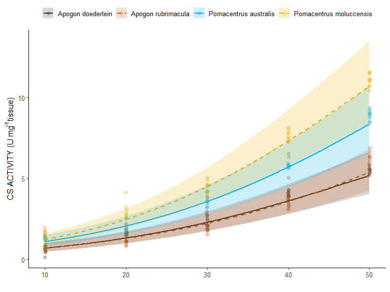

```r
cs.emm <- emmeans(cs.model.1.p2.log, ~temperature|LATITUDE|LATIN_GENUS,
                   at = list(temperature = seq(from =10, to =50, by =.1)),
                   type = "response")

cs.emm.df <- cs.emm %>% as.data.frame() %>%
  unite("species", c("LATIN_GENUS","LATITUDE"), sep = "-", remove = FALSE)

cs.obs <-  CS.data %>%
  mutate(Pred=exp(predict(cs.model.1.p2.log, re.form=NA)),
         Resid = residuals(cs.model.1.p2.log,  type="response"),
         Fit = Pred + Resid) %>%
   unite("species", c("LATIN_GENUS","LATITUDE"), sep = "-", remove = FALSE)


cs.plot <- ggplot(cs.emm.df, aes(y=response, x=temperature, linetype=species, color = species, fill=species))+
  geom_jitter(data=cs.obs,
              aes(y=Fit, color = species),
              width=0.05,
              alpha = 0.3,
              size = 2) +
  geom_line(linewidth =1) +
  geom_ribbon(aes(x=temperature,
              ymin= lower.CL, ymax= upper.CL),
              alpha = 0.2,
              color=NA)+
  #scale_x_continuous(limits = c(9, 52),
                     #breaks = seq(10, 52, by = 10))+
  #scale_y_continuous(limits = c(0,16), breaks = seq(0, 16, by = 2)) +
  theme_classic() +
  ylab(expression("CS ACTIVITY (U mg "^{-1} * "tissue)")) +
  xlab("")+
  scale_linetype_manual(values = c("solid", "dashed","solid", "dashed"),
                        labels = c("Apogon doederlein","Apogon rubrimacula","Pomacentrus australis", "Pomacentrus moluccensis"))+
  scale_color_manual(values=c("#3F3525","#C65C1B",  "#07AFF2", "#EAAE00"),
                        labels = c("Apogon doederlein","Apogon rubrimacula","Pomacentrus australis", "Pomacentrus moluccensis")) +
  scale_fill_manual(values=c("#3F3525","#C65C1B",  "#07AFF2", "#EAAE00"),
                        labels = c("Apogon doederlein","Apogon rubrimacula","Pomacentrus australis", "Pomacentrus moluccensis")) +
  theme(legend.position = "top",
        legend.text = element_text(size = 10),
        legend.title = element_blank(),
        axis.title = element_text(size =12),
        axis.text = element_text(size=10)); cs.plot
```

## Arrhenius plot

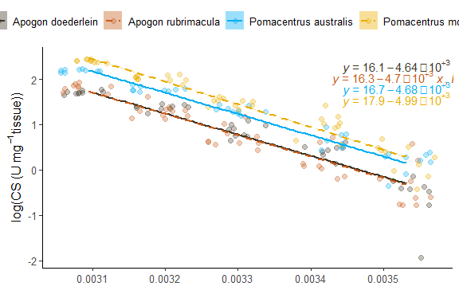

```r
cs.arrhenius.plot <- ggplot(cs.emm.df, aes(y=log(response), x=1/(temperature+273.15), linetype=species, color = species, fill=species))+
  geom_jitter(data=cs.obs,
              aes(y=log(Fit), color = species),
              #width=0.005,
              alpha = 0.3,
              size = 2) +
  stat_poly_line(method="lm", se = TRUE) +
  stat_poly_eq(use_label(c("eq", "R2")), hjust = -1.6)+
  #geom_ribbon(aes(x=1/(temperature+273.15),
              #ymin= log(asymp.LCL), ymax= log(asymp.UCL)),
              #alpha = 0.2,
              #color=NA)+
  #scale_x_continuous(limits = c(9, 52),
                     #breaks = seq(10, 52, by = 10))+
  #scale_y_continuous(limits = c(0,120), breaks = seq(0, 120, by = 20)) +
  theme_classic() +
  ylab(expression("log(CS (U mg "^{-1} * "tissue))")) +
  xlab("")+
  scale_linetype_manual(values = c("solid", "dashed","solid", "dashed"),
                        labels = c("Apogon doederlein","Apogon rubrimacula","Pomacentrus australis", "Pomacentrus moluccensis"))+
  scale_color_manual(values=c("#3F3525","#C65C1B",  "#07AFF2", "#EAAE00"),
                        labels = c("Apogon doederlein","Apogon rubrimacula","Pomacentrus australis", "Pomacentrus moluccensis")) +
  scale_fill_manual(values=c("#3F3525","#C65C1B",  "#07AFF2", "#EAAE00"),
                        labels = c("Apogon doederlein","Apogon rubrimacula","Pomacentrus australis", "Pomacentrus moluccensis")) +
  theme(legend.position = "top",
        legend.text = element_text(size = 10),
        legend.title = element_blank(),
        axis.title = element_text(size =12),
        axis.text = element_text(size=10)); cs.arrhenius.plot
```

# CS:LDH ratio

## Merge dataframes

To start we will merge the lactate dehydrogenase (LDH) and citrate synthase (CS) dataframes

```r
lc.data <- CS.data |>
  left_join(select(ldh.data, c("UNIQUE_SAMPLE_ID","LDH_ACTIVITY")), by = "UNIQUE_SAMPLE_ID") |>
  mutate(LDHCS = LDH_ACTIVITY/CS_ACTIVITY) |>
  drop_na(LDHCS)
```

## Initial plot

**LDH:CS v TEMPERATURE [SPECIES]**

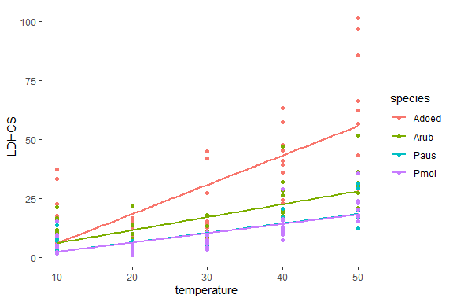

```r
ggplot(lc.data, aes(x =temperature, y= LDHCS, color = species)) +
  geom_point() +
  stat_smooth(method = "lm", se=FALSE) +
  theme_classic()
```

**LDH:CS [distribution]**

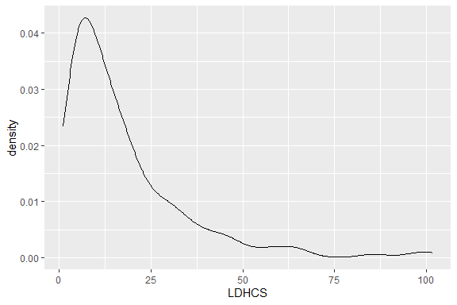

```r
ggplot(lc.data, aes(x = LDHCS, fill = temperature, color = temperature)) +
  geom_density(alpha =0.5, position = "identity")
```

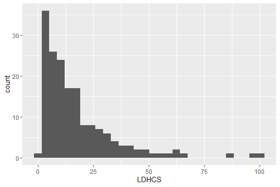

```r
ggplot(lc.data, aes(x=LDHCS)) + geom_histogram()
```

**LDH:CS v TEMPERATURE [LATITUDE]**

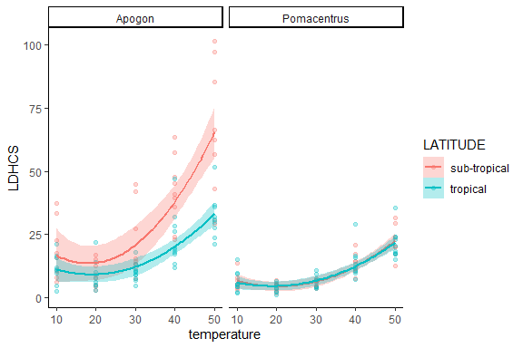

```r
ggplot(lc.data, aes(x =temperature, y= LDHCS, colour = LATITUDE, fill=LATITUDE)) +   geom_point(alpha=0.3) + stat_smooth(method = "lm", se=TRUE,  formula=y ~ poly(x, 2, raw=TRUE), alpha=0.3) + facet_grid(~LATIN_GENUS) + theme_classic()
```

**LDH:CS v TEMPERATURE [GENUS]**

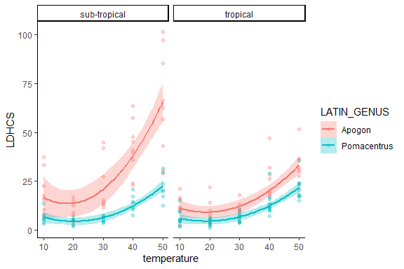

```r
ggplot(lc.data, aes(x =temperature, y= LDHCS, colour = LATIN_GENUS, fill=LATIN_GENUS)) +   geom_point(alpha=0.3) + stat_smooth(method = "lm", se=TRUE,  formula=y ~ poly(x, 2, raw=TRUE), alpha=0.3) + facet_grid(~LATITUDE) + theme_classic()
```

**LDH:CS v TEMPERATURE [SPECIES]**

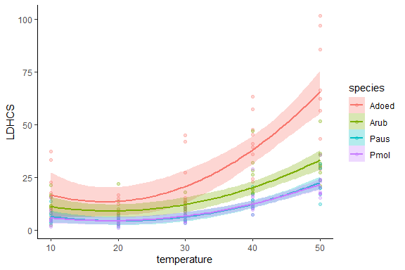

```r
ggplot(lc.data, aes(x =temperature, y= LDHCS, colour = species, fill= species)) +   geom_point(alpha=0.3) + stat_smooth(method = "lm", se=TRUE,  formula=y ~ poly(x, 2, raw=TRUE), alpha=0.3) + theme_classic()
```

## Fit the model

The model was fit using the **glm** and later **glmmTMB** packages in R. A number of different models were tested to determine which hypothesis and associated variables best predicted enzyme activity when measured as a ratio between lactate dehygronease and citrate synthase. Model fit was examined using AICc, BIC, and r-squared values. Additional model were examined via the validation diagnostics provided by the **performance**,**dHARMA**, and **plot_model** packages in R.

From out initial plots we can see that our data is heavily skewed to the right. From our initial plots we can all see that the relationship between enzyme activity (LDH:CS) and temperature is not linear, but rather may represent either a quadratic or cubic relationship. Let’s start out model selection process by comparing different polynomial models.

### polynomial models

```r
#--- model 1 ---#
lc.model.1 <- glm(LDHCS ~ temperature * LATITUDE * LATIN_GENUS,
               family = gaussian(),
               data = lc.data)

lc.model.1.p2 <- glm(LDHCS ~ poly(temperature, 2) * LATITUDE * LATIN_GENUS,
               family = gaussian(),
               data = lc.data)

lc.model.1.p3 <- glm(LDHCS ~ poly(temperature, 3) * LATITUDE * LATIN_GENUS,
               family = gaussian(),
               data = lc.data)
```

#### model comparisons - polynomial models

```r
aic.c=AICc(lc.model.1, lc.model.1.p2, lc.model.1.p3, k=2)
bic=BIC(lc.model.1, lc.model.1.p2, lc.model.1.p3)

model.fit.table <- as.data.frame(aic.c) %>%
  tibble::rownames_to_column("model") %>%
  mutate(BIC = bic$BIC,
         r2 = c(r.squaredLR(lc.model.1)[1], r.squaredLR(lc.model.1.p2)[1], r.squaredLR(lc.model.1.p3)[1]))
model.fit.table %>% knitr::kable(format = "html")  %>%
  kable_paper(full_width = TRUE)
```

| model | df | AICc | BIC | r2 |
| --- | --- | --- | --- | --- |
| lc.model.1 | 9 | 1322.276 | 1349.552 | 0.6234160 |
| lc.model.1.p2 | 13 | 1281.040 | 1319.743 | 0.7186253 |
| lc.model.1.p3 | 17 | 1284.989 | 1334.647 | 0.7277605 |

```r
anova(lc.model.1, lc.model.1.p2, lc.model.1.p3, test = "Chisq")
```

|  | Resid. Df | Resid. Dev | Df | Deviance | Pr(>Chi) |
| --- | --- | --- | --- | --- | --- |
| 1 | 165 | 18924.27 | NA | NA | NA |
| 2 | 161 | 14139.77 | 4 | 4784.5025 | 3.398008e-11 |
| 3 | 157 | 13680.70 | 4 | 459.0681 | 2.608617e-01 |

|  | Resid. Df <dbl> | Resid. Dev <dbl> | Df <dbl> | Deviance <dbl> | Pr(>Chi) <dbl> |
| --- | --- | --- | --- | --- | --- |
| 1 | 165 | 18924.27 | NA | NA | NA |
| 2 | 161 | 14139.77 | 4 | 4784.5025 | 3.398008e-11 |
| 3 | 157 | 13680.70 | 4 | 459.0681 | 2.608617e-01 |

3 rows

Looks like the model where temperature is treated as a second order polynomial (quadratic model) is better than the first and third order polynomial models. **Tissue mass** did not improve the model when looking at either lactate dehydrogenase or citrate synthase, therefore we will not be including it in the LDH:CS ratio analysis.

Because tissue samples from the same fish were tested at multiple temperatures we need to include **fish_id** as a random factor.

### Generalised linear mixed model (GLMM)

```r
lc.model.1.p2 <- glmmTMB(LDHCS ~ poly(temperature, 2) * LATITUDE * LATIN_GENUS + (1|fish_id),
               family = gaussian(),
               REML = TRUE,
               data = lc.data)
```

Great! Now lets check our model validations to see how the model is performing.

## Model validation

**lc.model.1 [performance]**

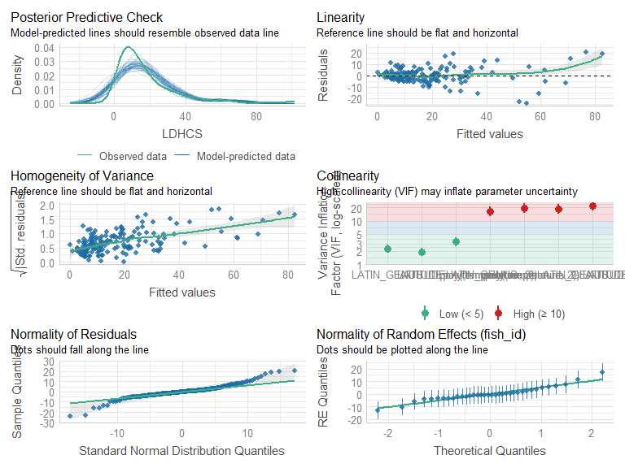

```r
lc.model.1.p2 %>% check_model(detrend = FALSE)
```

**lc.model.1 [DHARMa]**

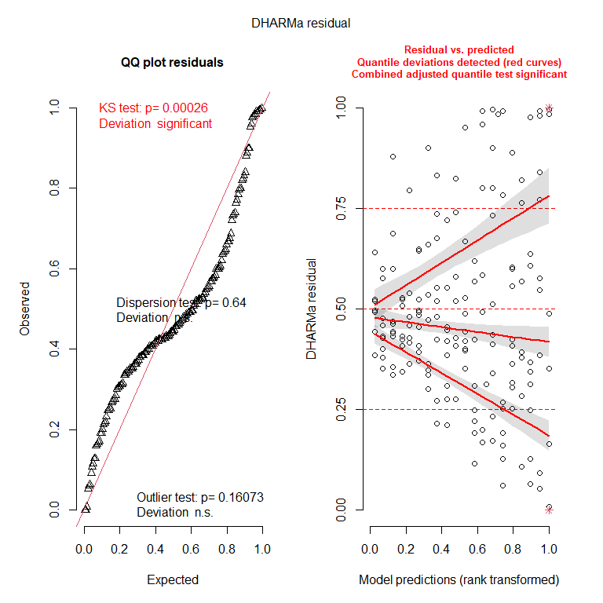

```
Object of Class DHARMa with simulated residuals based on 250 simulations with refit = FALSE . See ?DHARMa::simulateResiduals for help.

Scaled residual values: 0.312 0.984 0.772 0.352 0.992 0.568 0.784 0.84 0.996 0.8 0.308 0.192 0.98 0.984 0.116 0.268 0.052 0 0.96 0.62 ...
```

```r
lc.model.1.p2 %>% simulateResiduals(plot=TRUE)
```

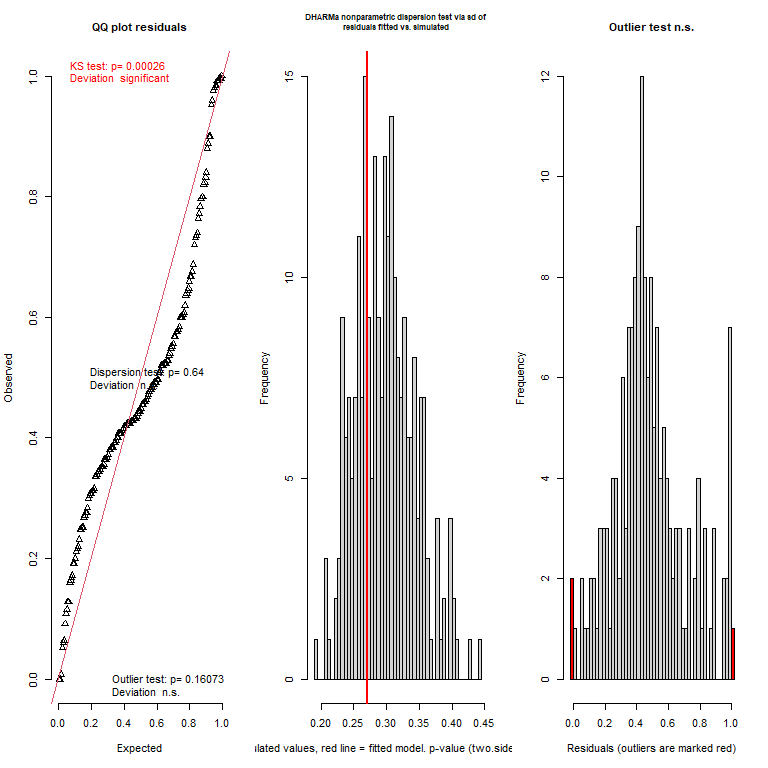

```
$uniformity

    Asymptotic one-sample Kolmogorov-Smirnov test

data:  simulationOutput$scaledResiduals
D = 0.16079, p-value = 0.0002608
alternative hypothesis: two-sided


$dispersion

    DHARMa nonparametric dispersion test via sd of residuals fitted vs.
    simulated

data:  simulationOutput
dispersion = 0.90942, p-value = 0.64
alternative hypothesis: two.sided


$outliers

    DHARMa outlier test based on exact binomial test with approximate
    expectations

data:  simulationOutput
outliers at both margin(s) = 3, observations = 173, p-value = 0.1607
alternative hypothesis: true probability of success is not equal to 0.007968127
95 percent confidence interval:
 0.003590516 0.049839268
sample estimates:
frequency of outliers (expected: 0.00796812749003984 )
                                            0.01734104
```

```
$uniformity

    Asymptotic one-sample Kolmogorov-Smirnov test

data:  simulationOutput$scaledResiduals
D = 0.16079, p-value = 0.0002608
alternative hypothesis: two-sided


$dispersion

    DHARMa nonparametric dispersion test via sd of residuals fitted vs.
    simulated

data:  simulationOutput
dispersion = 0.90942, p-value = 0.64
alternative hypothesis: two.sided


$outliers

    DHARMa outlier test based on exact binomial test with approximate
    expectations

data:  simulationOutput
outliers at both margin(s) = 3, observations = 173, p-value = 0.1607
alternative hypothesis: true probability of success is not equal to 0.007968127
95 percent confidence interval:
 0.003590516 0.049839268
sample estimates:
frequency of outliers (expected: 0.00796812749003984 )
                                            0.01734104
```

```r
lc.model.1.p2 %>% DHARMa::testResiduals(plot=TRUE)
```

**lc.model.1 [plot model]**

```
[[2]]
[[2]]$fish_id
```

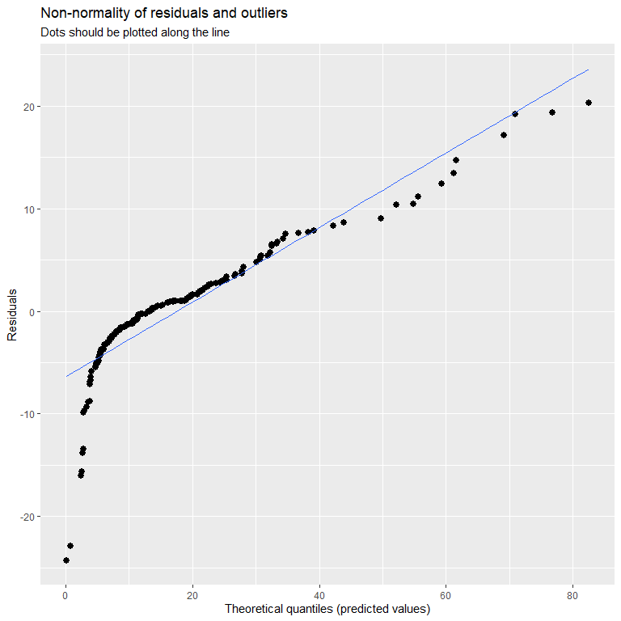

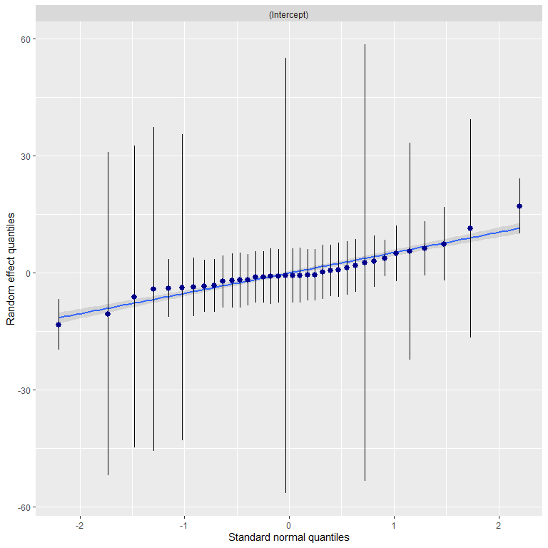

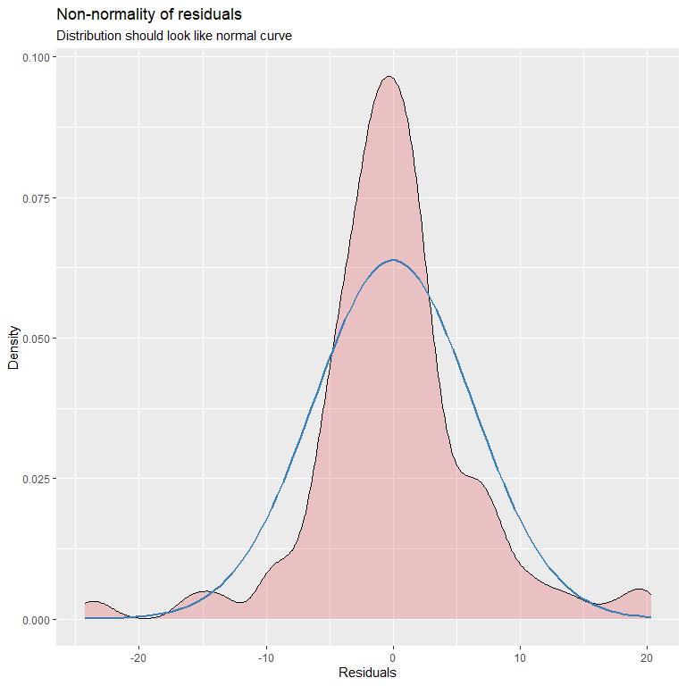

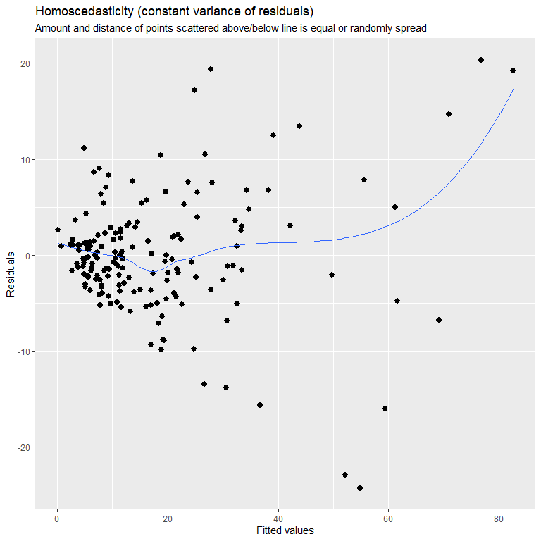

```r
par(mar=c(2,2,2,2))
lc.model.1.p2 %>% plot_model(type = "diag")
```

Our initial model (gaussian distribution) does not seem to function well. The predictive model does not fit the observed data, and the qq-plot also does not do a good job of ensuring that sample quantiles fit within the expectations of a gaussian distribution. Unexpectedly there are a number of issues also brought up with the DHARMa checks, KS-test is significant, and so is the deviation of the model quantiles from thier expectations. Similar trends can found in the plot_model output as well.

Lets start by changing the link distribution used within the model to see if this helps the model out.

## Re-fitting model

Turn **REML** off when comparing models

### re-fitting models [link functions]

```r
lc.model.1.p2 <-  lc.model.1.p2 %>% update(REML = FALSE)
lc.model.1.p2.log <- lc.model.1.p2 %>% update(family=gaussian(link="log"),
                                              REML=FALSE)
lc.model.1.p2.sqrt <- lc.model.1.p2 %>% update(family=gaussian(link="sqrt"),
                                               REML=FALSE)
```

### re-fit model comparisons [link function]

```r
aic.c=AICc(lc.model.1.p2, lc.model.1.p2.log, lc.model.1.p2.sqrt,  k=2)
bic=BIC(lc.model.1.p2, lc.model.1.p2.log, lc.model.1.p2.sqrt)

model.fit.table <- as.data.frame(aic.c) %>%
  tibble::rownames_to_column("model") %>%
  mutate(BIC = bic$BIC,
         r2 = c(r.squaredGLMM(lc.model.1.p2)[1], r.squaredGLMM(lc.model.1.p2.log)[1], r.squaredGLMM(lc.model.1.p2.sqrt)[1]))
model.fit.table %>% knitr::kable(format = "html")  %>%
  kable_paper(full_width = TRUE)
```

| model | df | AICc | BIC | r2 |
| --- | --- | --- | --- | --- |
| lc.model.1.p2 | 14 | 1241.877 | 1283.365 | 0.7204611 |
| lc.model.1.p2.log | 14 | 1186.484 | 1227.972 | 0.0146486 |
| lc.model.1.p2.sqrt | 14 | 1199.505 | 1240.992 | 0.0599157 |

```r
anova(lc.model.1.p2, lc.model.1.p2.log, lc.model.1.p2.sqrt, test = "Chisq")
```

|  | Df | AIC | BIC | logLik | deviance | Chisq | Chi Df | Pr(>Chisq) |
| --- | --- | --- | --- | --- | --- | --- | --- | --- |
| lc.model.1.p2 | 14 | 1239.219 | 1283.365 | -605.6096 | 1211.219 | NA | NA | NA |
| lc.model.1.p2.log | 14 | 1183.826 | 1227.972 | -577.9130 | 1155.826 | 55.39307 | 0 | 0 |
| lc.model.1.p2.sqrt | 14 | 1196.846 | 1240.992 | -584.4232 | 1168.846 | 0.00000 | 0 | 1 |

|  | Df <dbl> | AIC <dbl> | BIC <dbl> | logLik <dbl> | deviance <dbl> | Chisq <dbl> | Chi Df <dbl> | Pr(>Chisq) <dbl> |
| --- | --- | --- | --- | --- | --- | --- | --- | --- |
| lc.model.1.p2 | 14 | 1239.219 | 1283.365 | -605.6096 | 1211.219 | NA | NA | NA |
| lc.model.1.p2.log | 14 | 1183.826 | 1227.972 | -577.9130 | 1155.826 | 55.39307 | 0 | 0 |
| lc.model.1.p2.sqrt | 14 | 1196.846 | 1240.992 | -584.4232 | 1168.846 | 0.00000 | 0 | 1 |

3 rows

From our model outputs it looks like transforming the data via a log-link function seems to help. However, we will have to explore that data further as the r-squared value drops drastically

## Model re-validation

```r
lc.model.1.p2.log <- lc.model.1.p2.log %>% update(REML=TRUE)
```

**lc.model.1.p2.log [performance]**

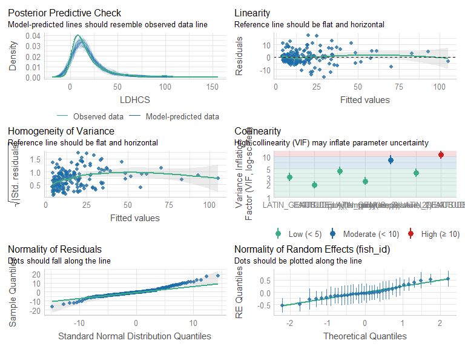

```r
lc.model.1.p2.log %>% check_model(detrend=FALSE)
```

**lc.model.1.p2.log [DHARMa]**

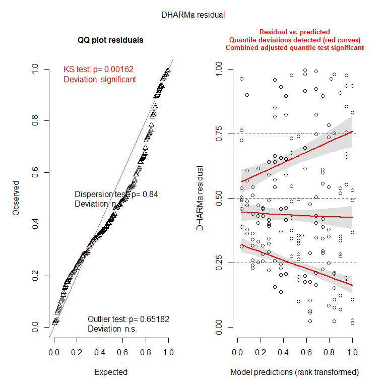

```
## Object of Class DHARMa with simulated residuals based on 250 simulations with refit = FALSE . See ?DHARMa::simulateResiduals for help.
##
## Scaled residual values: 0.356 0.964 0.756 0.492 0.996 0.476 0.752 0.856 0.936 0.916 0.176 0.152 0.936 0.832 0.024 0.208 0.176 0.028 0.98 0.476 ...
```

```r
lc.model.1.p2.log %>% simulateResiduals(plot=TRUE)
```

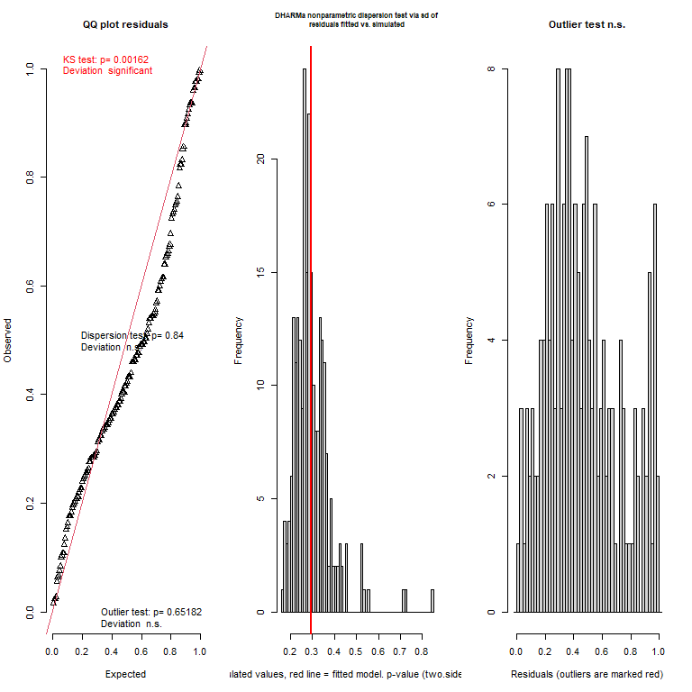

```
## $uniformity
##
##  Asymptotic one-sample Kolmogorov-Smirnov test
##
## data:  simulationOutput$scaledResiduals
## D = 0.14342, p-value = 0.001622
## alternative hypothesis: two-sided
##
##
## $dispersion
##
##  DHARMa nonparametric dispersion test via sd of residuals fitted vs.
##  simulated
##
## data:  simulationOutput
## dispersion = 0.98092, p-value = 0.84
## alternative hypothesis: two.sided
##
##
## $outliers
##
##  DHARMa outlier test based on exact binomial test with approximate
##  expectations
##
## data:  simulationOutput
## outliers at both margin(s) = 0, observations = 173, p-value = 0.6518
## alternative hypothesis: true probability of success is not equal to 0.007968127
## 95 percent confidence interval:
##  0.00000000 0.02109727
## sample estimates:
## frequency of outliers (expected: 0.00796812749003984 )
##                                                      0
```

```
## $uniformity
##
##  Asymptotic one-sample Kolmogorov-Smirnov test
##
## data:  simulationOutput$scaledResiduals
## D = 0.14342, p-value = 0.001622
## alternative hypothesis: two-sided
##
##
## $dispersion
##
##  DHARMa nonparametric dispersion test via sd of residuals fitted vs.
##  simulated
##
## data:  simulationOutput
## dispersion = 0.98092, p-value = 0.84
## alternative hypothesis: two.sided
##
##
## $outliers
##
##  DHARMa outlier test based on exact binomial test with approximate
##  expectations
##
## data:  simulationOutput
## outliers at both margin(s) = 0, observations = 173, p-value = 0.6518
## alternative hypothesis: true probability of success is not equal to 0.007968127
## 95 percent confidence interval:
##  0.00000000 0.02109727
## sample estimates:
## frequency of outliers (expected: 0.00796812749003984 )
##                                                      0
```

```r
lc.model.1.p2.log %>% DHARMa::testResiduals(plot=TRUE)
```

**plot_model**

```
##
## [[2]]
## [[2]]$fish_id
```

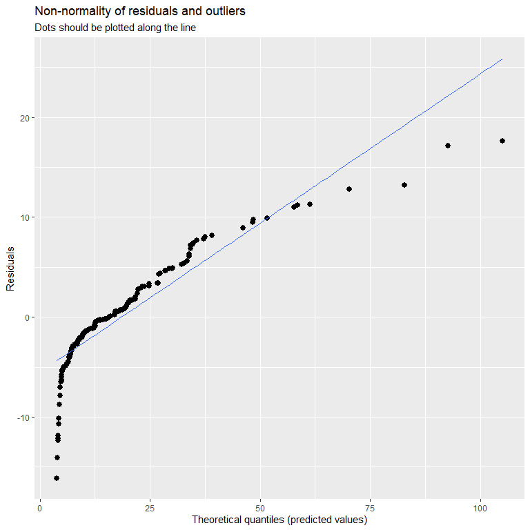

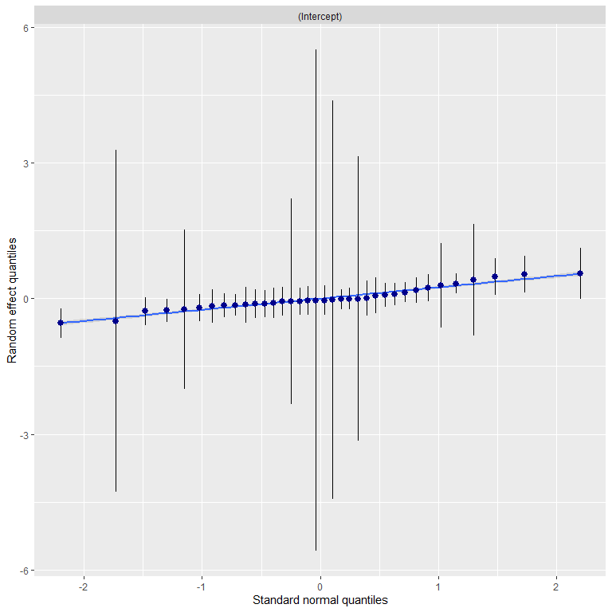

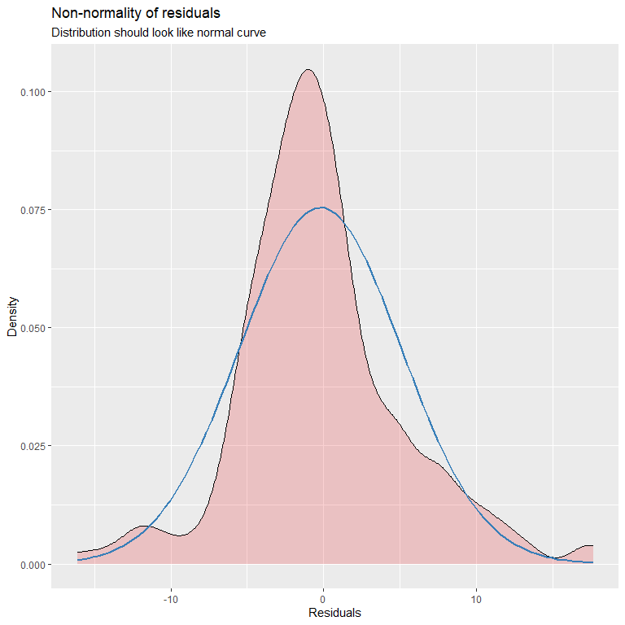

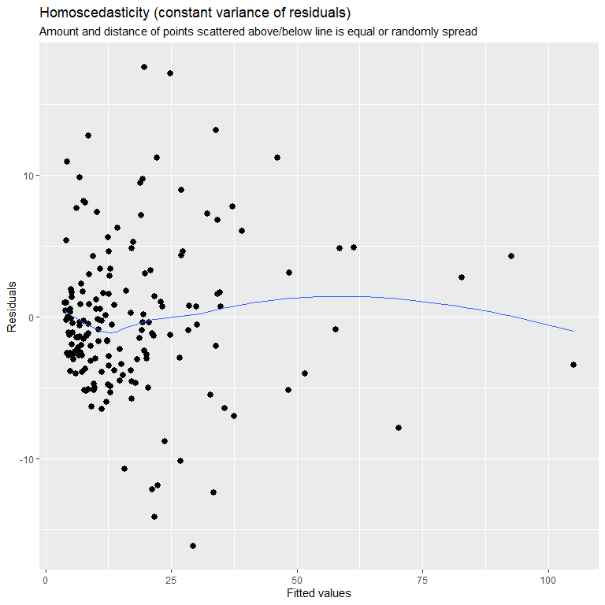

```r
par(mar=c(2,2,2,2))
lc.model.1.p2.log %>% plot_model(type = "diag")
```

### {-}

The log-link version of the model still has a number of issues, including a significant results for KS-test and quantile distributions, which shows that predicted data does not match the expected quantiles of a gaussian distribution and therefore violates assumptions within the gaussian distribution.

Because out data is continuous and all positive we can try to see if a Gamma distribution does a better job at modelling the data. We can also try fitting a Gamma distribution with a log-link function as well (the default for gamma is ‘inverse’).

## Re-re-fitting model

Turn **REML** off when comparing models

### re-fitting models [link functions]

```r
lc.model.1.p2 <-  lc.model.1.p2 %>% update(REML = FALSE)
lc.model.1.p2.log <-  lc.model.1.p2.log %>% update(REML = FALSE)
lc.model.1.p2.gamma <- lc.model.1.p2 %>% update(family=Gamma(),
                                              REML=FALSE)
lc.model.1.p2.gamma.log <- lc.model.1.p2 %>% update(family=Gamma(link="log"),
                                              REML=FALSE)
```

```r
aic.c=AICc(lc.model.1.p2, lc.model.1.p2.log, lc.model.1.p2.gamma, lc.model.1.p2.gamma.log,   k=2)
bic=BIC(lc.model.1.p2, lc.model.1.p2.log, lc.model.1.p2.gamma, lc.model.1.p2.gamma.log )

model.fit.table <- as.data.frame(aic.c) %>%
  tibble::rownames_to_column("model") %>%
  mutate(BIC = bic$BIC,
         r2 = c(r.squaredGLMM(lc.model.1.p2)[1], r.squaredGLMM(lc.model.1.p2.log)[1], r.squaredGLMM(lc.model.1.p2.gamma)[1], r.squaredGLMM(lc.model.1.p2.gamma.log)[1]))
model.fit.table %>% knitr::kable(format = "html")  %>%
  kable_paper(full_width = TRUE)
```

| model | df | AICc | BIC | r2 |
| --- | --- | --- | --- | --- |
| lc.model.1.p2 | 14 | 1241.877 | 1283.365 | 0.7204611 |
| lc.model.1.p2.log | 14 | 1186.484 | 1227.972 | 0.0146486 |
| lc.model.1.p2.gamma | 14 | NA | NA | 0.1047859 |
| lc.model.1.p2.gamma.log | 14 | 1114.203 | 1155.691 | 0.7005747 |

```r
anova(lc.model.1.p2, lc.model.1.p2.log, lc.model.1.p2.gamma, lc.model.1.p2.gamma.log,  test = "Chisq")
```

|  | Df | AIC | BIC | logLik | deviance | Chisq | Chi Df | Pr(>Chisq) |
| --- | --- | --- | --- | --- | --- | --- | --- | --- |
| lc.model.1.p2 | 14 | 1239.219 | 1283.365 | -605.6096 | 1211.219 | NA | NA | NA |
| lc.model.1.p2.log | 14 | 1183.826 | 1227.972 | -577.9130 | 1155.826 | 55.39307 | 0 | 0 |
| lc.model.1.p2.gamma | 14 | NA | NA | NA | NA | NA | 0 | NA |
| lc.model.1.p2.gamma.log | 14 | 1111.544 | 1155.691 | -541.7722 | 1083.544 | NA | 0 | NA |

|  | Df <dbl> | AIC <dbl> | BIC <dbl> | logLik <dbl> | deviance <dbl> | Chisq <dbl> | Chi Df <dbl> |  |
| --- | --- | --- | --- | --- | --- | --- | --- | --- |
| lc.model.1.p2 | 14 | 1239.219 | 1283.365 | -605.6096 | 1211.219 | NA | NA |  |
| lc.model.1.p2.log | 14 | 1183.826 | 1227.972 | -577.9130 | 1155.826 | 55.39307 | 0 |  |
| lc.model.1.p2.gamma | 14 | NA | NA | NA | NA | NA | 0 |  |
| lc.model.1.p2.gamma.log | 14 | 1111.544 | 1155.691 | -541.7722 | 1083.544 | NA | 0 |  |

4 rows | 1-8 of 9 columns

The gamma model seems to help when using a log. Lets look at the model validation to see if it is an appropriate model to use.

## Model re-re-validation

Turn REML on

```r
lc.model.1.p2.gamma.log <- lc.model.1.p2.gamma.log %>% update(REML=TRUE)
```

**[performance]**

#### lc.model.1.p2.gamma.log

```r
# lc.model.1.p2.gamma.log %>% check_model(detrend=FALSE)
```

**[DHARMa]**

#### lc.model.1.p2.gamma.log

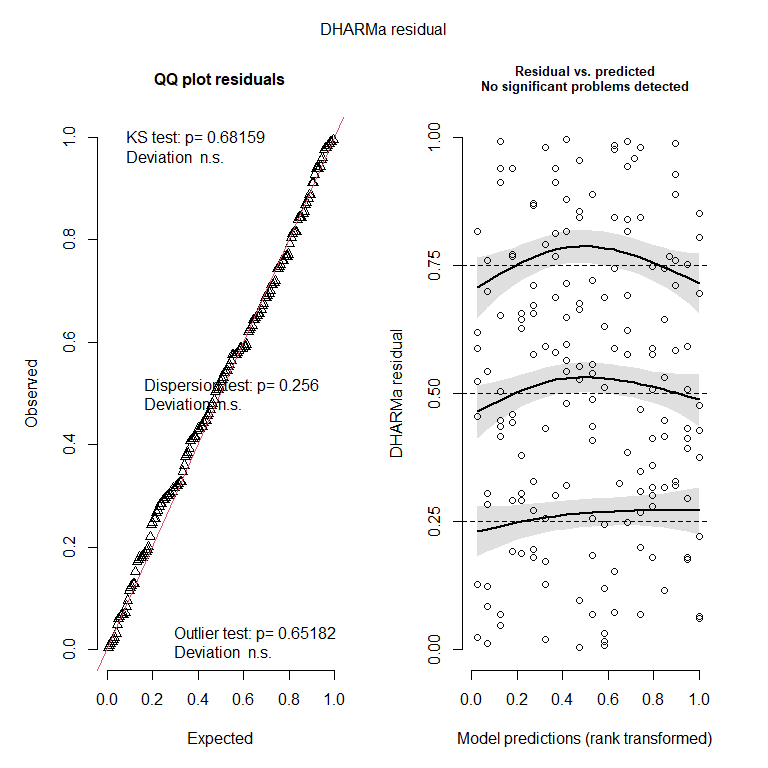

```
## Object of Class DHARMa with simulated residuals based on 250 simulations with refit = FALSE . See ?DHARMa::simulateResiduals for help.
##
## Scaled residual values: 0.324 0.96 0.768 0.428 0.984 0.632 0.844 0.888 0.804 0.844 0.244 0.308 0.928 0.696 0.008 0.348 0.32 0.064 0.976 0.688 ...
```

```r
lc.model.1.p2.gamma.log %>% simulateResiduals(plot=TRUE)
```

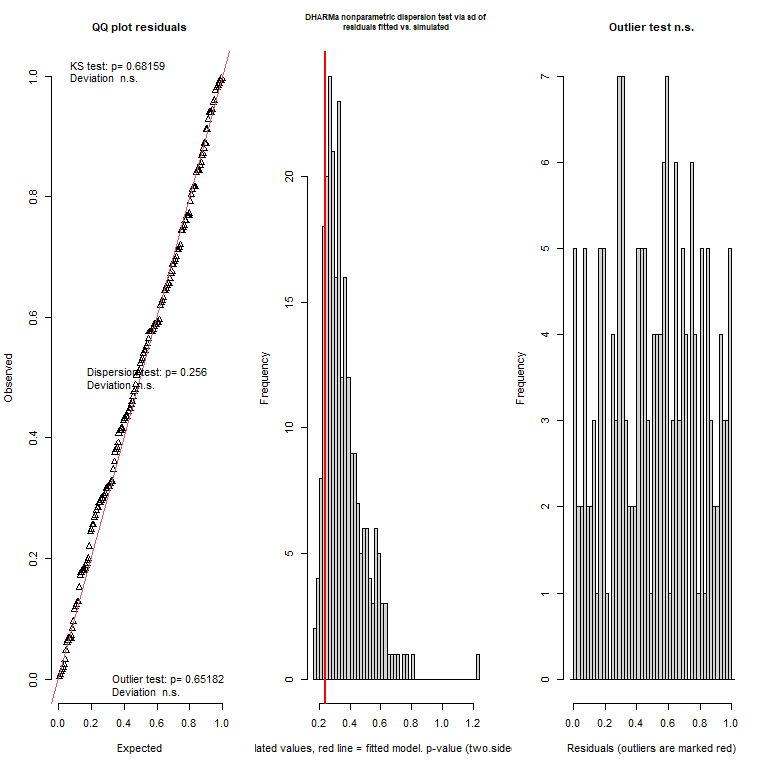

```
## $uniformity
##
##  Asymptotic one-sample Kolmogorov-Smirnov test
##
## data:  simulationOutput$scaledResiduals
## D = 0.054566, p-value = 0.6816
## alternative hypothesis: two-sided
##
##
## $dispersion
##
##  DHARMa nonparametric dispersion test via sd of residuals fitted vs.
##  simulated
##
## data:  simulationOutput
## dispersion = 0.65625, p-value = 0.256
## alternative hypothesis: two.sided
##
##
## $outliers
##
##  DHARMa outlier test based on exact binomial test with approximate
##  expectations
##
## data:  simulationOutput
## outliers at both margin(s) = 0, observations = 173, p-value = 0.6518
## alternative hypothesis: true probability of success is not equal to 0.007968127
## 95 percent confidence interval:
##  0.00000000 0.02109727
## sample estimates:
## frequency of outliers (expected: 0.00796812749003984 )
##                                                      0
```

```
## $uniformity
##
##  Asymptotic one-sample Kolmogorov-Smirnov test
##
## data:  simulationOutput$scaledResiduals
## D = 0.054566, p-value = 0.6816
## alternative hypothesis: two-sided
##
##
## $dispersion
##
##  DHARMa nonparametric dispersion test via sd of residuals fitted vs.
##  simulated
##
## data:  simulationOutput
## dispersion = 0.65625, p-value = 0.256
## alternative hypothesis: two.sided
##
##
## $outliers
##
##  DHARMa outlier test based on exact binomial test with approximate
##  expectations
##
## data:  simulationOutput
## outliers at both margin(s) = 0, observations = 173, p-value = 0.6518
## alternative hypothesis: true probability of success is not equal to 0.007968127
## 95 percent confidence interval:
##  0.00000000 0.02109727
## sample estimates:
## frequency of outliers (expected: 0.00796812749003984 )
##                                                      0
```

```r
lc.model.1.p2.gamma.log %>% DHARMa::testResiduals(plot=TRUE)
```

This model does not violate any assumptions and therefore we can start to look at the results.

## Partial plots

**ggemmeans**

**TEMPERATURE V LATITUDE**

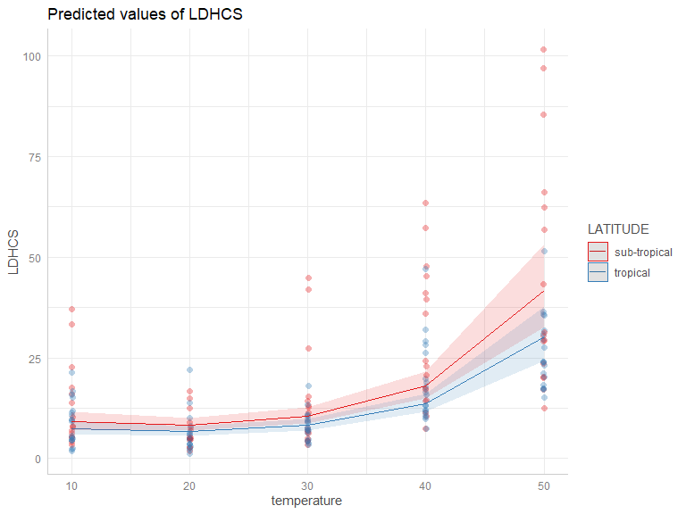

**TEMPERATURE V GENUS**

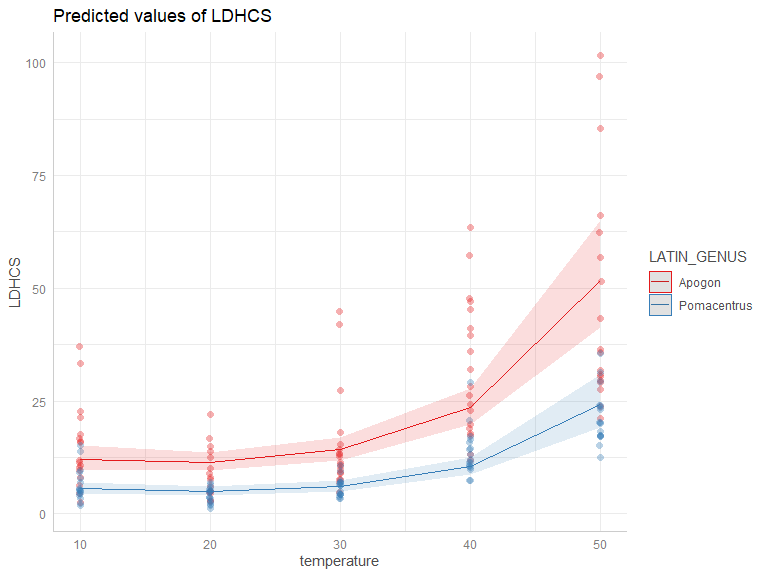

**TEMPERATURE V GENUS V LATITUDE**

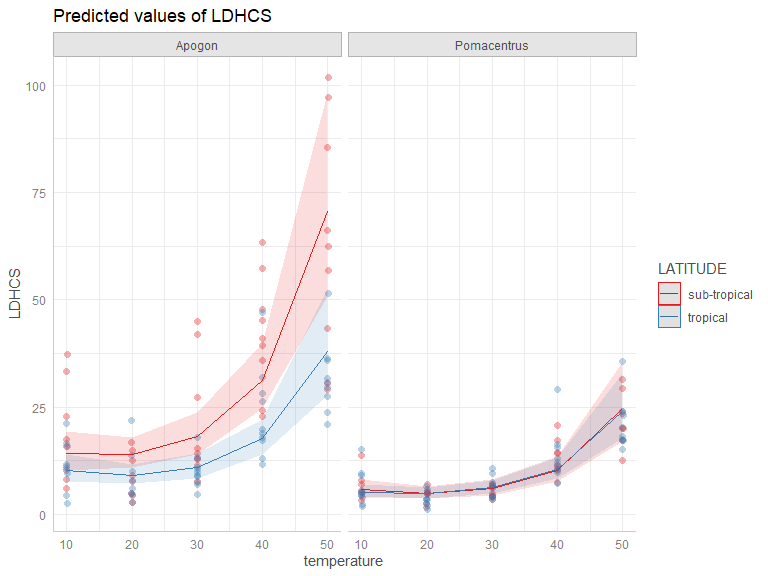

**plot_model**

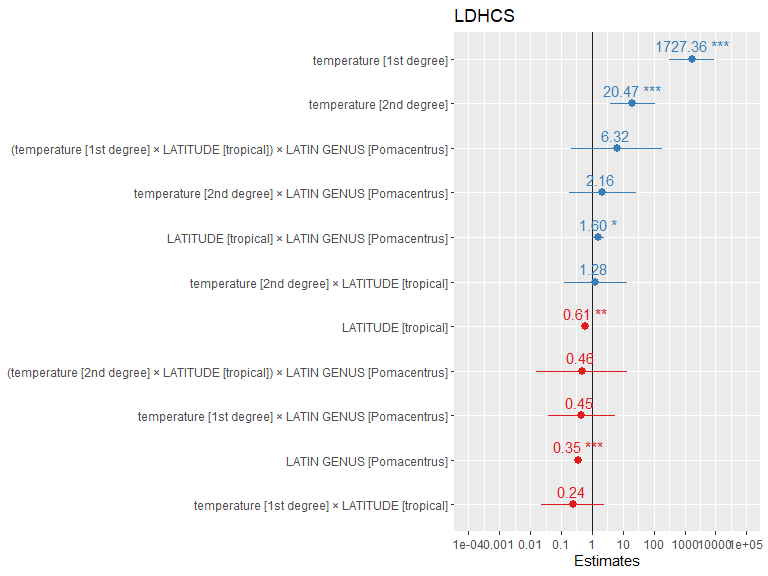

## Model investigation

**summary**

|  | Estimate | StdError | Zvalue | Pvalue |
| --- | --- | --- | --- | --- |
| (Intercept) | 3.1918267 | 0.1110721 | 28.7365278 | 0.0000000 |
| poly(temperature, 2)1 | 7.4543468 | 0.8588077 | 8.6798786 | 0.0000000 |
| poly(temperature, 2)2 | 3.0191493 | 0.8487234 | 3.5572830 | 0.0003747 |
| LATITUDEtropical | -0.4893076 | 0.1533872 | -3.1900166 | 0.0014226 |
| LATIN_GENUSPomacentrus | -1.0388517 | 0.1667533 | -6.2298710 | 0.0000000 |
| poly(temperature, 2)1:LATITUDEtropical | -1.4253208 | 1.2047969 | -1.1830383 | 0.2367940 |
| poly(temperature, 2)2:LATITUDEtropical | 0.2483000 | 1.1942321 | 0.2079160 | 0.8352945 |
| poly(temperature, 2)1:LATIN_GENUSPomacentrus | -0.7966207 | 1.2689419 | -0.6277834 | 0.5301458 |
| poly(temperature, 2)2:LATIN_GENUSPomacentrus | 0.7685689 | 1.2787626 | 0.6010255 | 0.5478230 |
| LATITUDEtropical:LATIN_GENUSPomacentrus | 0.4705187 | 0.2234879 | 2.1053434 | 0.0352614 |
| poly(temperature, 2)1:LATITUDEtropical:LATIN_GENUSPomacentrus | 1.8441406 | 1.7215611 | 1.0712025 | 0.2840784 |
| poly(temperature, 2)2:LATITUDEtropical:LATIN_GENUSPomacentrus | -0.7677930 | 1.7225153 | -0.4457395 | 0.6557855 |

**anova**

|  | Chisq | Df | Pr(>Chisq) |
| --- | --- | --- | --- |
| poly(temperature, 2) | 287.5221645 | 2 | 0.0000000 |
| LATITUDE | 5.8827771 | 1 | 0.0152897 |
| LATIN_GENUS | 48.9161596 | 1 | 0.0000000 |
| poly(temperature, 2):LATITUDE | 0.3740709 | 2 | 0.8294143 |
| poly(temperature, 2):LATIN_GENUS | 0.1972849 | 2 | 0.9060666 |
| LATITUDE:LATIN_GENUS | 4.4702398 | 1 | 0.0344902 |
| poly(temperature, 2):LATITUDE:LATIN_GENUS | 1.4745763 | 2 | 0.4784095 |

**confint**

|  | 2.5 % | 97.5 % | Estimate |
| --- | --- | --- | --- |
| (Intercept) | 2.9741294 | 3.4095241 | 3.1918267 |
| poly(temperature, 2)1 | 5.7711146 | 9.1375790 | 7.4543468 |
| poly(temperature, 2)2 | 1.3556820 | 4.6826166 | 3.0191493 |
| LATITUDEtropical | -0.7899409 | -0.1886743 | -0.4893076 |
| LATIN_GENUSPomacentrus | -1.3656823 | -0.7120212 | -1.0388517 |
| poly(temperature, 2)1:LATITUDEtropical | -3.7866793 | 0.9360376 | -1.4253208 |
| poly(temperature, 2)2:LATITUDEtropical | -2.0923519 | 2.5889518 | 0.2483000 |
| poly(temperature, 2)1:LATIN_GENUSPomacentrus | -3.2837011 | 1.6904597 | -0.7966207 |
| poly(temperature, 2)2:LATIN_GENUSPomacentrus | -1.7377598 | 3.2748977 | 0.7685689 |
| LATITUDEtropical:LATIN_GENUSPomacentrus | 0.0324905 | 0.9085469 | 0.4705187 |
| poly(temperature, 2)1:LATITUDEtropical:LATIN_GENUSPomacentrus | -1.5300572 | 5.2183383 | 1.8441406 |
| poly(temperature, 2)2:LATITUDEtropical:LATIN_GENUSPomacentrus | -4.1438610 | 2.6082749 | -0.7677930 |
| Std.Dev.(Intercept)\|fish_id | 0.1872062 | 0.3928469 | 0.2711888 |

**r-squared**

| R2_conditional | R2_marginal | optional |
| --- | --- | --- |
| 0.7772554 | 0.6828331 | FALSE |

## Pairwise comparisons

**emtrends**

```r
lc.model.1.p2.gamma.log %>% emtrends(var = "temperature", type = "response") %>% pairs(by = "temperature") %>% summary(by = NULL, adjust = "sidak", infer=TRUE)
```

[output not shown]

**emmeans**

```r
lc.model.1.p2.gamma.log %>% emmeans(pairwise ~ temperature*LATITUDE*LATIN_GENUS, type = "response") %>% regrid() %>% pairs(by = "temperature") %>% summary(by = NULL, adjust = "sidak", infer=TRUE)
```

|  | contrast | temperature | estimate | SE | df | asymp.LCL | asymp.UCL | z.ratio | p.value |
| --- | --- | --- | --- | --- | --- | --- | --- | --- | --- |
| 1 | (sub-tropical Apogon) - tropical Apogon | 30.34682 | 7.4272848 | 2.871479 | Inf | -0.1276869 | 14.982256 | 2.5865710 | 5.677031e-02 |
| 2 | (sub-tropical Apogon) - (sub-tropical Pomacentrus) | 30.34682 | 12.4213387 | 2.653975 | Inf | 5.4386293 | 19.404048 | 4.6802775 | 1.718909e-05 |
| 3 | (sub-tropical Apogon) - tropical Pomacentrus | 30.34682 | 12.2477886 | 2.612309 | Inf | 5.3747030 | 19.120874 | 4.6884911 | 1.651350e-05 |
| 4 | tropical Apogon - (sub-tropical Pomacentrus) | 30.34682 | 4.9940539 | 1.711986 | Inf | 0.4897542 | 9.498354 | 2.9171121 | 2.101099e-02 |
| 5 | tropical Apogon - tropical Pomacentrus | 30.34682 | 4.8205038 | 1.646691 | Inf | 0.4879957 | 9.153012 | 2.9273875 | 2.033490e-02 |
| 6 | (sub-tropical Pomacentrus) - tropical Pomacentrus | 30.34682 | -0.1735501 | 1.225141 | Inf | -3.3969436 | 3.049843 | -0.1416572 | 9.999980e-01 |

|  | contrast <fct> | temperature <dbl> | estimate <dbl> | SE <dbl> |  |
| --- | --- | --- | --- | --- | --- |
| 1 | (sub-tropical Apogon) - tropical Apogon | 30.34682 | 7.4272848 | 2.871479 |  |
| 2 | (sub-tropical Apogon) - (sub-tropical Pomacentrus) | 30.34682 | 12.4213387 | 2.653975 |  |
| 3 | (sub-tropical Apogon) - tropical Pomacentrus | 30.34682 | 12.2477886 | 2.612309 |  |
| 4 | tropical Apogon - (sub-tropical Pomacentrus) | 30.34682 | 4.9940539 | 1.711986 |  |
| 5 | tropical Apogon - tropical Pomacentrus | 30.34682 | 4.8205038 | 1.646691 |  |
| 6 | (sub-tropical Pomacentrus) - tropical Pomacentrus | 30.34682 | -0.1735501 | 1.225141 |  |

6 rows | 1-5 of 10 columns

**emmeans [ratios]**

```r
lc.model.1.p2.gamma.log %>% emmeans(pairwise ~ temperature*LATITUDE*LATIN_GENUS, type = "response") %>% regrid(transform="log") %>% pairs(by = "temperature") %>% summary(by = NULL, adjust = "sidak", infer=FALSE)
```

|  | contrast | temperature | ratio | SE | df |
| --- | --- | --- | --- | --- | --- |
| 1 | (sub-tropical Apogon) / tropical Apogon | 30.3468208092486 | 1.6680323 | 0.3106712 | Inf |
| 2 | (sub-tropical Apogon) / (sub-tropical Pomacentrus) | 30.3468208092486 | 3.0282724 | 0.6123832 | Inf |
| 3 | (sub-tropical Apogon) / tropical Pomacentrus | 30.3468208092486 | 2.9448195 | 0.5441339 | Inf |
| 4 | tropical Apogon / (sub-tropical Pomacentrus) | 30.3468208092486 | 1.8154758 | 0.3615971 | Inf |
| 5 | tropical Apogon / tropical Pomacentrus | 30.3468208092486 | 1.7654451 | 0.3202806 | Inf |
| 6 | (sub-tropical Pomacentrus) / tropical Pomacentrus | 30.3468208092486 | 0.9724421 | 0.1922662 | Inf |

|  | contrast <fct> | temperature <fct> | ratio <dbl> | SE <dbl> |  |
| --- | --- | --- | --- | --- | --- |
| 1 | (sub-tropical Apogon) / tropical Apogon | 30.3468208092486 | 1.6680323 | 0.3106712 |  |
| 2 | (sub-tropical Apogon) / (sub-tropical Pomacentrus) | 30.3468208092486 | 3.0282724 | 0.6123832 |  |
| 3 | (sub-tropical Apogon) / tropical Pomacentrus | 30.3468208092486 | 2.9448195 | 0.5441339 |  |
| 4 | tropical Apogon / (sub-tropical Pomacentrus) | 30.3468208092486 | 1.8154758 | 0.3615971 |  |
| 5 | tropical Apogon / tropical Pomacentrus | 30.3468208092486 | 1.7654451 | 0.3202806 |  |
| 6 | (sub-tropical Pomacentrus) / tropical Pomacentrus | 30.3468208092486 | 0.9724421 | 0.1922662 |  |

6 rows | 1-5 of 6 columns

**temperature**

```r
lc.model.1.p2.gamma.log %>% emmeans(~ temperature*LATITUDE*LATIN_GENUS, type = "response")  %>% summary(infer=TRUE)
```

|  | temperature | LATITUDE | LATIN_GENUS | response | SE | df | asymp.LCL | asymp.UCL | null | z.ratio | p.value |
| --- | --- | --- | --- | --- | --- | --- | --- | --- | --- | --- | --- |
| 1 | 30.34682 | sub-tropical | Apogon | 18.545437 | 2.4868706 | Inf | 14.259170 | 24.120142 | 1 | 21.77710 | 3.825501e-105 |
| 2 | 30.34682 | tropical | Apogon | 11.118152 | 1.4393784 | Inf | 8.626494 | 14.329495 | 1 | 18.60452 | 2.953110e-77 |
| 3 | 30.34682 | sub-tropical | Pomacentrus | 6.124098 | 0.9270516 | Inf | 4.551864 | 8.239389 | 1 | 11.97159 | 5.005879e-33 |
| 4 | 30.34682 | tropical | Pomacentrus | 6.297648 | 0.8010043 | Inf | 4.908098 | 8.080599 | 1 | 14.46782 | 1.935198e-47 |

|  | temperature <dbl> | LATITUDE <fct> | LATIN_GENUS <fct> | response <dbl> |  |
| --- | --- | --- | --- | --- | --- |
| 1 | 30.34682 | sub-tropical | Apogon | 18.545437 |  |
| 2 | 30.34682 | tropical | Apogon | 11.118152 |  |
| 3 | 30.34682 | sub-tropical | Pomacentrus | 6.124098 |  |
| 4 | 30.34682 | tropical | Pomacentrus | 6.297648 |  |

4 rows | 1-5 of 12 columns

**temperture [combined]**

```r
lc.means.temp <- lc.model.1.p2.gamma.log %>% update(LDHCS ~ factor(temperature) * LATITUDE * LATIN_GENUS + (1|fish_id)) %>% emmeans(pairwise ~ temperature, type = "response")
```

```
## NOTE: Results may be misleading due to involvement in interactions
```

```r
lc.means.temp.df <- lc.means.temp$emmeans %>% as.data.frame() %>%
  mutate("\u394 change"=response - lag(response, n=1, default = first(response)),
         "\u394 %change" = response/lag(response, n=1, default = first(response))*100)
lc.means.temp.df[1,8] = 0.0000

lc.means.temp.df
```

|  | temperature | response | SE | df | asymp.LCL | asymp.UCL | Δ change | Δ %change |
| --- | --- | --- | --- | --- | --- | --- | --- | --- |
| 1 | 10 | 9.112587 | 0.7338097 | Inf | 7.782103 | 10.670541 | 0.000000 | 0.00000 |
| 2 | 20 | 5.641113 | 0.4623865 | Inf | 4.803903 | 6.624231 | -3.471474 | 61.90463 |
| 3 | 30 | 8.841914 | 0.6938526 | Inf | 7.581408 | 10.311996 | 3.200801 | 156.74059 |
| 4 | 40 | 19.906201 | 1.5584462 | Inf | 17.074510 | 23.207508 | 11.064287 | 225.13452 |
| 5 | 50 | 30.876824 | 2.4388666 | Inf | 26.448363 | 36.046778 | 10.970623 | 155.11159 |

|  | temperature <dbl> | response <dbl> | SE <dbl> | df <dbl> |  |
| --- | --- | --- | --- | --- | --- |
| 1 | 10 | 9.112587 | 0.7338097 | Inf |  |
| 2 | 20 | 5.641113 | 0.4623865 | Inf |  |
| 3 | 30 | 8.841914 | 0.6938526 | Inf |  |
| 4 | 40 | 19.906201 | 1.5584462 | Inf |  |
| 5 | 50 | 30.876824 | 2.4388666 | Inf |  |

5 rows | 1-5 of 9 columns

**Genus [combined]**

```r
lc.means.genus <- lc.model.1.p2.gamma.log %>% update(LDHCS ~ factor(temperature) * LATITUDE * LATIN_GENUS + (1|fish_id)) %>% emmeans(pairwise ~ LATIN_GENUS, type = "response") %>% summary(infer=TRUE); lc.means.genus
```

```
## NOTE: Results may be misleading due to involvement in interactions
```

```
## $emmeans
##  LATIN_GENUS response    SE  df asymp.LCL asymp.UCL null z.ratio p.value
##  Apogon         18.25 1.396 Inf     15.71     21.20    1  37.973  <.0001
##  Pomacentrus     8.26 0.671 Inf      7.05      9.69    1  26.024  <.0001
##
## Results are averaged over the levels of: temperature, LATITUDE
## Confidence level used: 0.95
## Intervals are back-transformed from the log scale
## Tests are performed on the log scale
##
## $contrasts
##  contrast             ratio    SE  df asymp.LCL asymp.UCL null z.ratio p.value
##  Apogon / Pomacentrus  2.21 0.246 Inf      1.77      2.75    1   7.106  <.0001
##
## Results are averaged over the levels of: temperature, LATITUDE
## Confidence level used: 0.95
## Intervals are back-transformed from the log scale
## Tests are performed on the log scale
```

**Means - f(temperature)**

```r
lc.means <- lc.model.1.p2.gamma.log %>% update(LDHCS ~ factor(temperature) * LATITUDE * LATIN_GENUS + (1|fish_id)) %>% emmeans(pairwise ~ temperature*LATIN_GENUS*LATITUDE, type = "response")

lc.means.df <- lc.means$emmeans %>% as.data.frame() %>%
  mutate("change"=response - lag(response, n=1, default = first(response)),
         "%change" = response/lag(response, n=1, default = first(response))*100) %>%
  mutate("%change" = case_when(temperature == 10 ~ 0,
                                     TRUE ~ `%change`),
         "change" = case_when(temperature == 10 ~ 0,
                                     TRUE ~ `change`)) %>%
  rename("\u394 %change" = "%change",
         "\u394 change" = "change")

lc.means.df %>% knitr::kable(format = "html")  %>%
  kable_paper(full_width = TRUE)
```

| temperature | LATIN_GENUS | LATITUDE | response | SE | df | asymp.LCL | asymp.UCL | Δ change | Δ %change |
| --- | --- | --- | --- | --- | --- | --- | --- | --- | --- |
| 10 | Apogon | sub-tropical | 16.640930 | 2.7154268 | Inf | 12.085944 | 22.912613 | 0.0000000 | 0.00000 |
| 20 | Apogon | sub-tropical | 8.392900 | 1.3630461 | Inf | 6.104822 | 11.538548 | -8.2480299 | 50.43528 |
| 30 | Apogon | sub-tropical | 19.089620 | 2.9776722 | Inf | 14.061239 | 25.916178 | 10.6967190 | 227.44961 |
| 40 | Apogon | sub-tropical | 40.354658 | 6.2465610 | Inf | 29.794414 | 54.657844 | 21.2650387 | 211.39582 |
| 50 | Apogon | sub-tropical | 59.597329 | 9.2375287 | Inf | 43.983661 | 80.753661 | 19.2426711 | 147.68389 |
| 10 | Pomacentrus | sub-tropical | 6.340568 | 1.1180577 | Inf | 4.487788 | 8.958265 | 0.0000000 | 0.00000 |
| 20 | Pomacentrus | sub-tropical | 4.362387 | 0.7684587 | Inf | 3.088732 | 6.161239 | -1.9781809 | 68.80120 |
| 30 | Pomacentrus | sub-tropical | 5.303728 | 0.9326075 | Inf | 3.757560 | 7.486115 | 0.9413412 | 121.57858 |
| 40 | Pomacentrus | sub-tropical | 13.267229 | 2.3289670 | Inf | 9.404980 | 18.715548 | 7.9635006 | 250.14911 |
| 50 | Pomacentrus | sub-tropical | 21.519073 | 3.7785385 | Inf | 15.253198 | 30.358913 | 8.2518445 | 162.19720 |
| 10 | Apogon | tropical | 11.151737 | 1.7230513 | Inf | 8.238035 | 15.095982 | 0.0000000 | 0.00000 |
| 20 | Apogon | tropical | 7.883144 | 1.2760497 | Inf | 5.740040 | 10.826399 | -3.2685922 | 70.68984 |
| 30 | Apogon | tropical | 9.790307 | 1.4411508 | Inf | 7.336651 | 13.064557 | 1.9071623 | 124.19291 |
| 40 | Apogon | tropical | 22.062176 | 3.2455107 | Inf | 16.535992 | 29.435163 | 12.2718698 | 225.34715 |
| 50 | Apogon | tropical | 33.652721 | 5.1494886 | Inf | 24.932774 | 45.422367 | 11.5905443 | 152.53582 |
| 10 | Pomacentrus | tropical | 5.860283 | 0.8677358 | Inf | 4.384101 | 7.833512 | 0.0000000 | 0.00000 |
| 20 | Pomacentrus | tropical | 3.508517 | 0.5381843 | Inf | 2.597495 | 4.739063 | -2.3517655 | 59.86942 |
| 30 | Pomacentrus | tropical | 6.166098 | 0.9068998 | Inf | 4.621862 | 8.226285 | 2.6575804 | 175.74654 |
| 40 | Pomacentrus | tropical | 13.293254 | 1.9557665 | Inf | 9.963192 | 17.736345 | 7.1271568 | 215.58618 |
| 50 | Pomacentrus | tropical | 21.060077 | 3.0940306 | Inf | 15.790872 | 28.087546 | 7.7668230 | 158.42680 |

**Abs. diff - f(temperature)**

```r
lc.model.1.p2.gamma.log %>% update(LDHCS ~ factor(temperature) * LATITUDE * LATIN_GENUS + (1|fish_id)) %>% emmeans(pairwise ~ temperature*LATIN_GENUS*LATITUDE, type = "response") %>% regrid() %>% pairs(by =c("LATIN_GENUS","LATITUDE")) %>% summary(infer=TRUE, type = "response")
```

|  | contrast | LATIN_GENUS | LATITUDE | estimate | SE | df | asymp.LCL | asymp.UCL | z.ratio | p.value |
| --- | --- | --- | --- | --- | --- | --- | --- | --- | --- | --- |
| 1 | temperature10 - temperature20 | Apogon | sub-tropical | 8.2480299 | 2.5739642 | Inf | 1.22683615 | 15.2692236 | 3.2044073 | 1.182112e-02 |
| 2 | temperature10 - temperature30 | Apogon | sub-tropical | -2.4486892 | 3.2509897 | Inf | -11.31665556 | 6.4192772 | -0.7532135 | 9.437311e-01 |
| 3 | temperature10 - temperature40 | Apogon | sub-tropical | -23.7137278 | 5.8557367 | Inf | -39.68685636 | -7.7405993 | -4.0496575 | 4.921655e-04 |
| 4 | temperature10 - temperature50 | Apogon | sub-tropical | -42.9563989 | 8.6400010 | Inf | -66.52437230 | -19.3884256 | -4.9718049 | 6.574392e-06 |
| 5 | temperature20 - temperature30 | Apogon | sub-tropical | -10.6967190 | 2.8130855 | Inf | -18.37018160 | -3.0232565 | -3.8024863 | 1.349528e-03 |
| 6 | temperature20 - temperature40 | Apogon | sub-tropical | -31.9617577 | 5.8945220 | Inf | -48.04068393 | -15.8828314 | -5.4222815 | 5.861853e-07 |
| 7 | temperature20 - temperature50 | Apogon | sub-tropical | -51.2044288 | 8.8355049 | Inf | -75.30569280 | -27.1031648 | -5.7953031 | 6.807480e-08 |
| 8 | temperature30 - temperature40 | Apogon | sub-tropical | -21.2650387 | 5.8394702 | Inf | -37.19379576 | -5.3362816 | -3.6416041 | 2.513423e-03 |
| 9 | temperature30 - temperature50 | Apogon | sub-tropical | -40.5077098 | 8.5934625 | Inf | -63.94873661 | -17.0666829 | -4.7137821 | 2.397666e-05 |
| 10 | temperature40 - temperature50 | Apogon | sub-tropical | -19.2426711 | 8.9764529 | Inf | -43.72840938 | 5.2430672 | -2.1436832 | 2.016335e-01 |

[output cut: 30 more lines]

|  | contrast <fct> | LATIN_GENUS <fct> | LATITUDE <fct> | estimate <dbl> |  |
| --- | --- | --- | --- | --- | --- |
| 1 | temperature10 - temperature20 | Apogon | sub-tropical | 8.2480299 |  |
| 2 | temperature10 - temperature30 | Apogon | sub-tropical | -2.4486892 |  |
| 3 | temperature10 - temperature40 | Apogon | sub-tropical | -23.7137278 |  |
| 4 | temperature10 - temperature50 | Apogon | sub-tropical | -42.9563989 |  |
| 5 | temperature20 - temperature30 | Apogon | sub-tropical | -10.6967190 |  |
| 6 | temperature20 - temperature40 | Apogon | sub-tropical | -31.9617577 |  |
| 7 | temperature20 - temperature50 | Apogon | sub-tropical | -51.2044288 |  |
| 8 | temperature30 - temperature40 | Apogon | sub-tropical | -21.2650387 |  |
| 9 | temperature30 - temperature50 | Apogon | sub-tropical | -40.5077098 |  |
| 10 | temperature40 - temperature50 | Apogon | sub-tropical | -19.2426711 |  |

1-10 of 40 rows | 1-5 of 11 columns

**effect size**

```r
lc.emm <- lc.model.1.p2.gamma.log %>% emmeans(~temperature*LATITUDE*LATIN_GENUS)
eff_size(lc.emm, sigma = sigma(lc.model.1.p2.gamma.log), edf=df.residual(lc.model.1.p2.gamma.log))
```

```
##  contrast
##  (temperature30.3468208092486 sub-tropical Apogon) - temperature30.3468208092486 tropical Apogon
##  (temperature30.3468208092486 sub-tropical Apogon) - (temperature30.3468208092486 sub-tropical Pomacentrus)
##  (temperature30.3468208092486 sub-tropical Apogon) - temperature30.3468208092486 tropical Pomacentrus
##  temperature30.3468208092486 tropical Apogon - (temperature30.3468208092486 sub-tropical Pomacentrus)
##  temperature30.3468208092486 tropical Apogon - temperature30.3468208092486 tropical Pomacentrus
##  (temperature30.3468208092486 sub-tropical Pomacentrus) - temperature30.3468208092486 tropical Pomacentrus
##  effect.size    SE  df asymp.LCL asymp.UCL
##       1.2284 0.452 Inf     0.342     2.114
##       2.6601 0.506 Inf     1.668     3.653
##       2.5930 0.465 Inf     1.681     3.505
##       1.4317 0.484 Inf     0.482     2.381
##       1.3646 0.442 Inf     0.499     2.230
##      -0.0671 0.475 Inf    -0.997     0.863
##
## sigma used for effect sizes: 0.4165
## Confidence level used: 0.95
```

## Summary figure

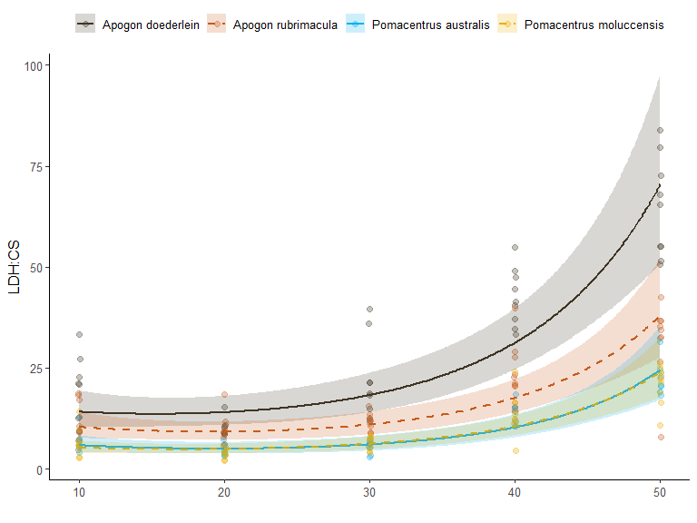

```r
lc.emm <- emmeans(lc.model.1.p2.gamma.log, ~temperature|LATITUDE|LATIN_GENUS,
                   at = list(temperature = seq(from =10, to =50, by =.1)),
                   type = "response")

lc.emm.df <- lc.emm %>% as.data.frame() %>%
  unite("species", c("LATIN_GENUS","LATITUDE"), sep = "-", remove = FALSE)

lc.obs <-  lc.data %>%
  mutate(Pred=exp(predict(lc.model.1.p2.gamma.log, re.form=NA)),
         Resid = residuals(lc.model.1.p2.gamma.log, type="response"),
         Fit = Pred + Resid) %>%
   unite("species", c("LATIN_GENUS","LATITUDE"), sep = "-", remove = FALSE)


lc.plot <- ggplot(lc.emm.df, aes(y=response, x=temperature, linetype=species, color = species, fill=species))+
  geom_jitter(data=lc.obs,
              aes(y=Fit, color = species),
              width=0.05,
              alpha = 0.3,
              size = 2) +
  geom_line(linewidth =1) +
  geom_ribbon(aes(x=temperature,
              ymin= asymp.LCL, ymax= asymp.UCL),
              alpha = 0.2,
              color=NA)+
  #scale_x_continuous(limits = c(9, 52),
                     #breaks = seq(10, 52, by = 10))+
  #scale_y_continuous(limits = c(0,120), breaks = seq(0, 120, by = 20)) +
  theme_classic() +
  ylab("LDH:CS") +
  xlab("")+
  scale_linetype_manual(values = c("solid", "dashed","solid", "dashed"),
                        labels = c("Apogon doederlein","Apogon rubrimacula","Pomacentrus australis", "Pomacentrus moluccensis")) +
  scale_color_manual(values=c("#3F3525","#C65C1B",  "#07AFF2", "#EAAE00"),
                        labels = c("Apogon doederlein","Apogon rubrimacula","Pomacentrus australis", "Pomacentrus moluccensis")) +
  scale_fill_manual(values=c("#3F3525","#C65C1B",  "#07AFF2", "#EAAE00"),
                        labels = c("Apogon doederlein","Apogon rubrimacula","Pomacentrus australis", "Pomacentrus moluccensis")) +
  theme(legend.position = "top",
        legend.text = element_text(size = 10),
        legend.title = element_blank(),
        axis.title = element_text(size =12),
        axis.text = element_text(size=10)); lc.plot
```

# Descriptive statistics

```r
lc.data2 <- CS.data |>
  full_join(select(ldh.data, c("UNIQUE_SAMPLE_ID","LDH_ACTIVITY")), by = "UNIQUE_SAMPLE_ID") |>
  mutate(LDHCS = LDH_ACTIVITY/CS_ACTIVITY) %>%
  separate(UNIQUE_SAMPLE_ID, into=c("LATIN_NAME_ABBREV","rep","temp"), sep="_", remove=FALSE) |>
  mutate(LATIN_NAME= case_when(LATIN_NAME_ABBREV =="Adoed"~ "Apogon doederlein",
                               LATIN_NAME_ABBREV =="Arub"~ "Apogon rubrimacula",
                               LATIN_NAME_ABBREV =="Pmol"~ "Pomacentrus moluccensis",
                               LATIN_NAME_ABBREV =="Paus"~ "Pomacentrus australis",
                               TRUE ~ LATIN_NAME
                   )) %>% select(c("LATIN_NAME", "temp", "CS_ACTIVITY", "LDH_ACTIVITY", "LDHCS")) %>%
  pivot_longer(!c(LATIN_NAME,temp), names_to = "enzyme") %>%
  drop_na(value)


lc.data.table <- table(lc.data2$LATIN_NAME,lc.data2$temp, lc.data2$enzyme) %>% as.data.frame()
table(lc.data2$LATIN_NAME,lc.data2$temp, lc.data2$enzyme)%>%
  knitr::kable(format = "html")  %>%
  kable_paper(full_width = TRUE)
```

| Var1 | Var2 | Var3 | Freq |
| --- | --- | --- | --- |
| Apogon doederlein | 10 | CS_ACTIVITY | 8 |
| Apogon rubrimacula | 10 | CS_ACTIVITY | 9 |
| Pomacentrus australis | 10 | CS_ACTIVITY | 9 |
| Pomacentrus moluccensis | 10 | CS_ACTIVITY | 10 |
| Apogon doederlein | 20 | CS_ACTIVITY | 8 |
| Apogon rubrimacula | 20 | CS_ACTIVITY | 8 |
| Pomacentrus australis | 20 | CS_ACTIVITY | 8 |
| Pomacentrus moluccensis | 20 | CS_ACTIVITY | 9 |
| Apogon doederlein | 30 | CS_ACTIVITY | 9 |
| Apogon rubrimacula | 30 | CS_ACTIVITY | 10 |
| Pomacentrus australis | 30 | CS_ACTIVITY | 9 |
| Pomacentrus moluccensis | 30 | CS_ACTIVITY | 10 |
| Apogon doederlein | 40 | CS_ACTIVITY | 9 |
| Apogon rubrimacula | 40 | CS_ACTIVITY | 10 |
| Pomacentrus australis | 40 | CS_ACTIVITY | 9 |
| Pomacentrus moluccensis | 40 | CS_ACTIVITY | 10 |
| Apogon doederlein | 50 | CS_ACTIVITY | 9 |
| Apogon rubrimacula | 50 | CS_ACTIVITY | 9 |
| Pomacentrus australis | 50 | CS_ACTIVITY | 9 |
| Pomacentrus moluccensis | 50 | CS_ACTIVITY | 10 |
| Apogon doederlein | 10 | LDH_ACTIVITY | 9 |
| Apogon rubrimacula | 10 | LDH_ACTIVITY | 10 |
| Pomacentrus australis | 10 | LDH_ACTIVITY | 8 |
| Pomacentrus moluccensis | 10 | LDH_ACTIVITY | 10 |
| Apogon doederlein | 20 | LDH_ACTIVITY | 9 |
| Apogon rubrimacula | 20 | LDH_ACTIVITY | 10 |
| Pomacentrus australis | 20 | LDH_ACTIVITY | 8 |
| Pomacentrus moluccensis | 20 | LDH_ACTIVITY | 10 |
| Apogon doederlein | 30 | LDH_ACTIVITY | 9 |
| Apogon rubrimacula | 30 | LDH_ACTIVITY | 10 |
| Pomacentrus australis | 30 | LDH_ACTIVITY | 8 |
| Pomacentrus moluccensis | 30 | LDH_ACTIVITY | 10 |
| Apogon doederlein | 40 | LDH_ACTIVITY | 9 |
| Apogon rubrimacula | 40 | LDH_ACTIVITY | 10 |
| Pomacentrus australis | 40 | LDH_ACTIVITY | 8 |
| Pomacentrus moluccensis | 40 | LDH_ACTIVITY | 10 |
| Apogon doederlein | 50 | LDH_ACTIVITY | 9 |
| Apogon rubrimacula | 50 | LDH_ACTIVITY | 10 |
| Pomacentrus australis | 50 | LDH_ACTIVITY | 8 |
| Pomacentrus moluccensis | 50 | LDH_ACTIVITY | 10 |
| Apogon doederlein | 10 | LDHCS | 8 |
| Apogon rubrimacula | 10 | LDHCS | 9 |
| Pomacentrus australis | 10 | LDHCS | 7 |
| Pomacentrus moluccensis | 10 | LDHCS | 10 |
| Apogon doederlein | 20 | LDHCS | 8 |
| Apogon rubrimacula | 20 | LDHCS | 8 |
| Pomacentrus australis | 20 | LDHCS | 7 |
| Pomacentrus moluccensis | 20 | LDHCS | 9 |
| Apogon doederlein | 30 | LDHCS | 9 |
| Apogon rubrimacula | 30 | LDHCS | 10 |
| Pomacentrus australis | 30 | LDHCS | 7 |
| Pomacentrus moluccensis | 30 | LDHCS | 10 |
| Apogon doederlein | 40 | LDHCS | 9 |
| Apogon rubrimacula | 40 | LDHCS | 10 |
| Pomacentrus australis | 40 | LDHCS | 7 |
| Pomacentrus moluccensis | 40 | LDHCS | 10 |
| Apogon doederlein | 50 | LDHCS | 9 |
| Apogon rubrimacula | 50 | LDHCS | 9 |
| Pomacentrus australis | 50 | LDHCS | 7 |
| Pomacentrus moluccensis | 50 | LDHCS | 10 |

# Figure

**Figure 1**

```r
#--- library ---#
library("magick")
library("grid")
ruby <- image_read("./fish_figures/PNG/Ostorhinchus_rubrimacula.png")
ruby.vector <- magick::image_ggplot(ruby, interpolate = TRUE)
ruby.image <- image_fill(ruby, 'none')
ruby.raster <- as.raster(ruby.image)

doed <- image_read_svg("./fish_figures/SVG/Ostorhinchus_doederleini.svg")
doed.vector <- magick::image_ggplot(doed, interpolate = TRUE)
doed.image <- image_fill(doed, 'none')
doed.raster <- as.raster(doed.image)

australia <- image_read_svg("./fish_figures/SVG/paustralis2.svg")
australia.vector <- magick::image_ggplot(australia, interpolate = TRUE)
australia.image <- image_fill(australia, 'none')
australia.raster <- as.raster(australia.image)

molu <- image_read_svg("./fish_figures/SVG/lemon_damselfish.svg")
molu.vector <- magick::image_ggplot(molu, interpolate = TRUE)
molu.image <- image_fill(molu, 'none')
molu.raster <- as.raster(molu.image)
#--- LDH plot ---#
ldh.emm <- emmeans(ldh.sqrt.model.1.p2, ~temperature|LATITUDE|LATIN_GENUS,
                   at = list(temperature = seq(from =10, to =50, by =.1)),
                   type = "response")

ldh.emm.df <- ldh.emm %>% as.data.frame() %>%
  unite("species", c("LATIN_GENUS","LATITUDE"), sep = "-", remove = FALSE)

ldh.obs <-  ldh.data %>%
  mutate(Pred=predict(ldh.sqrt.model.1.p2, re.form=NA, type="response"),
         Resid = residuals(ldh.sqrt.model.1.p2),
         Fit = Pred + Resid) %>%
   unite("species", c("LATIN_GENUS","LATITUDE"), sep = "-", remove = FALSE)


ldh.plot <- ggplot(ldh.emm.df, aes(y=response, x=temperature, linetype=species, color = species, fill=species))+
  geom_line(linewidth =1) +
  geom_ribbon(aes(x=temperature,
              ymin= lower.CL, ymax= upper.CL),
              alpha = 0.2,
              color=NA)+
  geom_jitter(data=ldh.obs,
              aes(y=Fit^2, color = species),
              width=0.05,
              alpha = 0.3,
              size = 2) +
  scale_x_continuous(limits = c(9, 56),
                     breaks = seq(10, 52, by = 10))+
  scale_y_continuous(limits = c(0,350), breaks = seq(0, 350, by = 50)) +
  theme_classic() +
  ylab(expression("LDH ACTIVITY (U mg "^{-1} * "tissue)")) +
  xlab("")+
  scale_linetype_manual(values = c("solid", "dashed","solid", "dashed"),
                        labels = c("Ostorhinchus doederlein \n (sub-tropical)","Ostorhinchus rubrimacula \n (tropical)","Pomacentrus australis \n (sub-tropical)", "Pomacentrus moluccensis \n (tropical)"))+
  scale_color_manual(values=c("#3F3525","#C65C1B",  "#07AFF2", "#EAAE00"),
                        labels = c("Ostorhinchus doederlein \n (sub-tropical)","Ostorhinchus rubrimacula \n (tropical)","Pomacentrus australis \n (sub-tropical)", "Pomacentrus moluccensis \n (tropical)")) +
  scale_fill_manual(values=c("#3F3525","#C65C1B",  "#07AFF2", "#EAAE00"),
                        labels = c("Ostorhinchus doederlein \n (sub-tropical)","Ostorhinchus rubrimacula \n (tropical)","Pomacentrus australis \n (sub-tropical)", "Pomacentrus moluccensis \n (tropical)")) +
  theme(legend.position = "none",
        legend.text = element_text(size = 12, face = "italic"),
        legend.title = element_blank(),
        axis.title = element_text(size =14),
        axis.text = element_text(size=12),
        axis.text.x = element_blank()) +
  annotation_raster(ruby.raster, 50, 56, 165, 215) +
  annotation_raster(doed.raster, 50, 56, 290, 340) +
  annotation_raster(australia.raster, 51, 56, 155, 205) +
  annotation_raster(molu.raster, 50, 56, 200, 250)

#--- citrate synthase plot ---#
cs.emm <- emmeans(cs.model.1.p2.log, ~temperature|LATITUDE|LATIN_GENUS,
                   at = list(temperature = seq(from =10, to =50, by =.1)),
                   type = "response")

cs.emm.df <- cs.emm %>% as.data.frame() %>%
  unite("species", c("LATIN_GENUS","LATITUDE"), sep = "-", remove = FALSE)

cs.obs <-  CS.data %>%
  mutate(Pred=exp(predict(cs.model.1.p2.log, re.form=NA)),
         Resid = residuals(cs.model.1.p2.log,  type="response"),
         Fit = Pred + Resid) %>%
   unite("species", c("LATIN_GENUS","LATITUDE"), sep = "-", remove = FALSE)


cs.plot <- ggplot(cs.emm.df, aes(y=response, x=temperature, linetype=species, color = species, fill=species))+
  geom_line(linewidth =1) +
  geom_ribbon(aes(x=temperature,
              ymin= lower.CL, ymax= upper.CL),
              alpha = 0.2,
              color=NA)+
  geom_jitter(data=cs.obs,
              aes(y=Fit, color = species),
              width=0.05,
              alpha = 0.3,
              size = 2) +
  scale_x_continuous(limits = c(9, 56),
                     breaks = seq(10, 52, by = 10))+
  scale_y_continuous(limits = c(0,16), breaks = seq(0, 16, by = 2)) +
  theme_classic() +
  ylab(expression("CS ACTIVITY (U mg "^{-1} * "tissue)")) +
  xlab("")+
  scale_linetype_manual(values = c("solid", "dashed","solid", "dashed"),
                        labels = c("Ostorhinchus doederlein (sub-tropical)","Ostorhinchus rubrimacula (tropical)","Pomacentrus australis(sub-tropical)", "Pomacentrus moluccensis (tropical)"))+
  scale_color_manual(values=c("#3F3525","#C65C1B",  "#07AFF2", "#EAAE00"),
                        labels = c("Ostorhinchus doederlein (sub-tropical)","Ostorhinchus rubrimacula (tropical)","Pomacentrus australis(sub-tropical)", "Pomacentrus moluccensis (tropical)")) +
  scale_fill_manual(values=c("#3F3525","#C65C1B",  "#07AFF2", "#EAAE00"),
                        labels = c("Ostorhinchus doederlein (sub-tropical)","Ostorhinchus rubrimacula (tropical)","Pomacentrus australis(sub-tropical)", "Pomacentrus moluccensis (tropical)")) +
  theme(legend.position = c(0.3,0.8),
        legend.text = element_text(size = 12, face = "italic"),
        legend.title = element_blank(),
        axis.title = element_text(size =14),
        axis.text = element_text(size=12),
        axis.text.x = element_blank()) +
  annotation_raster(ruby.raster, 50, 56, 4.5, 7) +
  annotation_raster(doed.raster, 51, 57, 4.3, 6.8) +
  annotation_raster(australia.raster, 50.5, 55, 7.5, 10) +
  annotation_raster(molu.raster, 50, 56, 10, 12.5)

#--- LDH:CS plot ---#
lc.emm <- emmeans(lc.model.1.p2.gamma.log, ~temperature|LATITUDE|LATIN_GENUS,
                   at = list(temperature = seq(from =10, to =50, by =.1)),
                   type = "response")

lc.emm.df <- lc.emm %>% as.data.frame() %>%
  unite("species", c("LATIN_GENUS","LATITUDE"), sep = "-", remove = FALSE)

lc.obs <-  lc.data %>%
  mutate(Pred=exp(predict(lc.model.1.p2.gamma.log, re.form=NA)),
         Resid = residuals(lc.model.1.p2.gamma.log, type="response"),
         Fit = Pred + Resid) %>%
   unite("species", c("LATIN_GENUS","LATITUDE"), sep = "-", remove = FALSE)


lc.plot <- ggplot(lc.emm.df, aes(y=response, x=temperature, linetype=species, color = species, fill=species))+
  geom_line(linewidth =1) +
  geom_ribbon(aes(x=temperature,
              ymin= asymp.LCL, ymax= asymp.UCL),
              alpha = 0.2,
              color=NA)+
  geom_jitter(data=lc.obs,
              aes(y=Fit, color = species),
              width=0.05,
              alpha = 0.3,
              size = 2) +
  scale_x_continuous(limits = c(9, 56),
                     breaks = seq(10, 52, by = 10))+
  scale_y_continuous(limits = c(0,120), breaks = seq(0, 120, by = 20)) +
  theme_classic() +
  ylab("LDH:CS ratio") +
  xlab("Temperature (°C)")+
  scale_linetype_manual(values = c("solid", "dashed","solid", "dashed"),
                        labels = c("Ostorhinchus doederlein \n (sub-tropical)","Ostorhinchus rubrimacula \n (tropical)","Pomacentrus australis \n (sub-tropical)", "Pomacentrus moluccensis \n (tropical)")) +
  scale_color_manual(values=c("#3F3525","#C65C1B",  "#07AFF2", "#EAAE00"),
                        labels = c("Ostorhinchus doederlein \n (sub-tropical)","Ostorhinchus rubrimacula \n (tropical)","Pomacentrus australis \n (sub-tropical)", "Pomacentrus moluccensis \n (tropical)")) +
  scale_fill_manual(values=c("#3F3525","#C65C1B",  "#07AFF2", "#EAAE00"),
                        labels = c("Ostorhinchus doederlein \n (sub-tropical)","Ostorhinchus rubrimacula \n (tropical)","Pomacentrus australis \n (sub-tropical)", "Pomacentrus moluccensis \n (tropical)")) +
  theme(legend.position = "none",
        legend.text = element_text(size = 12, face = "italic"),
        legend.title = element_blank(),
        axis.title = element_text(size =14),
        axis.text = element_text(size=12)) +
  guides(color = guide_legend(nrow=2)) +
  annotation_raster(ruby.raster, 50, 56, 30, 48) +
  annotation_raster(doed.raster, 50, 56, 65, 83) +
  annotation_raster(australia.raster, 50.5, 55, 18, 35) +
  annotation_raster(molu.raster, 51, 57, 16, 33)

species.plot <- ggarrange(cs.plot, ldh.plot, lc.plot,
         nrow = 3,
         ncol= 1,
         align = "hv",
         labels = c("A","B","C"),
         common.legend = FALSE); species.plot

ggsave(file="./02.Figures/Figure1/Figure1_species_plot.png",  plot=species.plot, width=8.5, height=15.5, units = "in", dpi=300)
ggsave(file="./02.Figures/Figure1/Figure1_species_plot2.png", plot=species.plot, width=7, height=12, units = "in", dpi=300)

ggsave(file="./02.Figures/Figure1/Figure1_species_plot.pdf",  plot=species.plot, width=8.5, height=15.5, units = "in", dpi=300)
ggsave(file="./02.Figures/Figure1/Figure1_species_plot2.pdf", plot=species.plot, width=7, height=12, units = "in", dpi=300)

ggsave(file="./02.Figures/Figure1/Figure1_species_plot.svg",  plot=species.plot, width=8.5, height=15.5, units = "in", dpi=300)
ggsave(file="./02.Figures/Figure1/Figure1_species_plot2.svg", plot=species.plot, width=7, height=12, units = "in", dpi=300)
```

**Supplemental Figure 1**

```r
#--- LDH plot ---#
ldh.temp.emm <- emmeans(ldh.sqrt.model.1.p2, ~temperature,
                   at = list(temperature = seq(from =10, to =50, by =.1)),
                   type = "response") %>% as.data.frame()

ldh.temp.obs <- ldh.data %>%
  mutate(Pred=predict(ldh.sqrt.model.1.p2, re.form=NA, type="response"),
         Resid = residuals(ldh.sqrt.model.1.p2),
         Fit = Pred + Resid)


ldh.temp.plot <- ggplot(ldh.temp.emm, aes(y=response, x=temperature))+
  geom_line(linewidth =1) +
  geom_ribbon(aes(x=temperature,
              ymin= lower.CL, ymax= upper.CL),
              alpha = 0.4,
              color=NA)+
  geom_jitter(data=ldh.temp.obs ,
              aes(y=Fit^2, fill = "black"),
              width=0.05,
              alpha = 0.3,
              size = 2)+
  scale_x_continuous(limits = c(9, 52),
                     breaks = seq(10, 52, by = 10))+
  scale_y_continuous(limits = c(0,350), breaks = seq(0, 350, by = 50)) +
  theme_classic() +
  ylab(expression("LDH ACTIVITY (U mg "^{-1} * "tissue)")) +
  xlab("TEMPERATURE (°C)")+
  theme(legend.position = "none",
        axis.title = element_text(size =12),
        axis.text = element_text(size=10)); ldh.temp.plot

#--- CS plot ---#
cs.temp.emm <- emmeans(cs.model.1.p2.log, ~temperature,
                   at = list(temperature = seq(from =10, to =50, by =.1)),
                   type = "response")

cs.temp.df <- cs.temp.emm %>% as.data.frame()

cs.temp.obs <-  CS.data %>%
  mutate(Pred=exp(predict(cs.model.1.p2.log, re.form=NA)),
         Resid = residuals(cs.model.1.p2.log,  type="response"),
         Fit = Pred + Resid)


cs.temp.plot <- ggplot(cs.temp.df, aes(y=response, x=temperature))+
  geom_jitter(data=cs.temp.obs,
              aes(y=Fit, fill="black"),
              width=0.05,
              alpha = 0.3,
              size = 2) +
  geom_line(linewidth =1) +
  geom_ribbon(aes(x=temperature,
              ymin= lower.CL, ymax= upper.CL),
              alpha = 0.2,
              color=NA)+
  scale_x_continuous(limits = c(9, 52),
                     breaks = seq(10, 52, by = 10))+
  scale_y_continuous(limits = c(0,12), breaks = seq(0, 12, by = 2)) +
  theme_classic() +
  ylab(expression("CS ACTIVITY (U mg "^{-1} * "tissue)")) +
  xlab(" ")+
  theme(legend.position = "none",
        axis.title = element_text(size =12),
        axis.text = element_text(size=10)); cs.temp.plot

temp.plot <- ggarrange(cs.temp.plot, ldh.temp.plot,
         nrow = 2,
         ncol= 1,
          align = "hv",
         labels = c("A","B"),
         common.legend = FALSE); temp.plot


ggsave(file="./02.Figures/SFigure1/SFigure1_temp_plot.svg",  plot=temp.plot, width=15.5, height=8.5, units = "in", dpi=300)
ggsave(file="./02.Figures/SFigure1/SFigure1_temp_plot2.svg", plot=temp.plot, width=12, height=7, units = "in", dpi=300)
#ggsave(file="./02.Figures/SFigure1/SFigure1_temp_plot3.svg", plot=temp.plot, width=8, height=5, units = "in", dpi=300)
ggsave(file="./02.Figures/SFigure1/SFigure1_temp_plot.pdf",  plot=temp.plot, width=15.5, height=8.5, units = "in", dpi=300)
ggsave(file="./02.Figures/SFigure1/SFigure1_temp_plot2.pdf", plot=temp.plot, width=12, height=7, units = "in", dpi=300)
#ggsave(file="./02.Figures/SFigure1/SFigure1_temp_plot3.pdf", plot=cs.genus.plot, width=8, height=5, units = "in", dpi=300)
```

**Supplemental Figure 2**

```r
cs.genus.emm <- emmeans(cs.model.1.p2.log, ~temperature|LATIN_GENUS,
                   at = list(temperature = seq(from =10, to =50, by =.1)),
                   type = "response") %>% as.data.frame()

cs.genus.obs <-  CS.data %>%
  mutate(Pred=exp(predict(cs.model.1.p2.log, re.form=NA)),
         Resid = residuals(cs.model.1.p2.log, type="response"),
         Fit = Pred + Resid)


cs.genus.plot <- ggplot(cs.genus.emm, aes(y=response, x=temperature, linetype=LATIN_GENUS, color = LATIN_GENUS, fill=LATIN_GENUS))+
  geom_line(linewidth =1) +
  geom_ribbon(aes(x=temperature,
              ymin= lower.CL, ymax= upper.CL),
              alpha = 0.4,
              color=NA)+
  geom_jitter(data=cs.genus.obs ,
              aes(y=Fit, color = LATIN_GENUS),
              width=0.05,
              alpha = 0.3,
              size = 2) +
  #scale_x_continuous(limits = c(9, 52),
                     #breaks = seq(10, 52, by = 10))+
  #scale_y_continuous(limits = c(0,120), breaks = seq(0, 120, by = 20)) +
  theme_classic() +
  ylab(expression("CS ACTIVITY (U mg "^{-1} * " tissue)")) +
  xlab("Temperature (°C)") +
  scale_linetype_manual(values = c("solid", "dashed"),
                        labels = c("Ostorhinchus","Pomacentrus")) +
  scale_color_manual(values=c("black","gray60"),
                        labels = c("Ostorhinchus","Pomacentrus")) +
  scale_fill_manual(values=c("black","gray60"),
                        labels = c("Ostorhinchus","Pomacentrus")) +
   theme(legend.position = c(0.2,0.85),
        legend.text = element_text(size = 14, face = "italic"),
        legend.title = element_blank(),
        axis.title = element_text(size =16),
        axis.text = element_text(size=14))



ggsave(file="./02.Figures/SFigure2/SFigure2_cs_genus_plot.svg",  plot=cs.genus.plot, width=15.5, height=8.5, units = "in", dpi=300)
ggsave(file="./02.Figures/SFigure2/SFigure2_cs_genus_plot2.svg", plot=cs.genus.plot, width=12, height=7, units = "in", dpi=300)
ggsave(file="./02.Figures/SFigure2/SFigure2_cs_genus_plot3.svg", plot=cs.genus.plot, width=8, height=5, units = "in", dpi=300)
ggsave(file="./02.Figures/SFigure2/SFigure2_cs_genus_plot.pdf",  plot=cs.genus.plot, width=15.5, height=8.5, units = "in", dpi=300)
ggsave(file="./02.Figures/SFigure2/SFigure2_cs_genus_plot2.pdf", plot=cs.genus.plot, width=12, height=7, units = "in", dpi=300)
ggsave(file="./02.Figures/SFigure2/SFigure2_cs_genus_plot3.pdf", plot=cs.genus.plot, width=8, height=5, units = "in", dpi=300)
```

**Supplemental Figure x**

```r
ldh.dperc.plot <- ggplot(ldh.means.temp.df, aes(x=temperature, y=`Δ %change`)) +
  geom_line(size=2) +
  geom_point(shape = 15, color="red", size = 3) +
  xlab("") + ylab(expression("\u394 % CHANGE IN LDH ACTIVITY (U mg "^{-1} * "tissue)"))+
  scale_x_continuous(limits = c(9, 52),
                     breaks = seq(10, 52, by = 10))+
  scale_y_continuous(limits = c(0,400), breaks = seq(0, 400, by = 50)) +
  theme_classic() +
  theme(axis.title = element_text(size =13),
        axis.text = element_text(size=12))

cs.dperc.plot <- ggplot(cs.means.temp.df, aes(x=temperature, y=`Δ %change`)) +
  geom_line(size=2) +
  geom_point(shape = 15, color="red", size = 3) +
  xlab("") + ylab(expression("\u394 % CHANGE IN CS ACTIVITY (U mg "^{-1} * "tissue)"))+
  scale_x_continuous(limits = c(9, 52),
                     breaks = seq(10, 52, by = 10))+
  scale_y_continuous(limits = c(0,250), breaks = seq(0, 250, by = 50)) +
  theme_classic()  +
  theme(axis.title = element_text(size =13),
        axis.text = element_text(size=12))

lc.dperc.plot <- ggplot(lc.means.temp.df, aes(x=temperature, y=`Δ %change`)) +
  geom_line(size=2) +
  geom_point(shape = 15, color="red", size = 3) +
  xlab("TEMPERATURE") + ylab(expression("\u394 % CHANGE IN LDH:CS RATIO"))+
  scale_x_continuous(limits = c(9, 52),
                     breaks = seq(10, 52, by = 10))+
  #scale_y_continuous(limits = c(0,250), breaks = seq(0, 250, by = 50)) +
  theme_classic()  +
  theme(axis.title = element_text(size =13),
        axis.text = element_text(size=12))

dchange.plot <- ggarrange(cs.dperc.plot, ldh.dperc.plot, lc.dperc.plot,
         nrow = 3,
         ncol= 1,
          align = "hv",
         labels = c("A","B","C"),
         common.legend = FALSE); dchange.plot

#ggsave(file="./02.Figures/SFigure2/SFigure2_dchange_plot.svg",  plot=dchange.plot, width=8.5, height=15.5, units = "in", dpi=300)
#ggsave(file="./02.Figures/SFigure2/SFigure2_dchange_plot2.svg", plot=dchange.plot, width=7, height=12, units = "in", dpi=300)
#ggsave(file="./02.Figures/SFigure2/SFigure2_dchange_plot3.svg", plot=dchange.plot, width=5, height=8, units = "in", dpi=300)
#ggsave(file="./02.Figures/SFigure2/SFigure2_dchange_plot.pdf",  plot=dchange.plot, width=8.5, height=15.5, units = "in", dpi=300)
#ggsave(file="./02.Figures/SFigure2/SFigure2_dchange_plot2.pdf", plot=dchange.plot, width=7, height=12, units = "in", dpi=300)
#ggsave(file="./02.Figures/SFigure2/SFigure2_dchange_plot3.pdf", plot=dchange.plot, width=5, height=8, units = "in", dpi=300)
```